# Coursework 1 - Supervised learning

**Replace CID in the file name with your CID**

# Outline

- Task 1: Regression
  - (1.1) Random Forest
    - (1.1.1)
    - (1.1.2)
    - (1.1.3)
  - (1.2) Multi-layer Perceptron
    - (1.2.1)
    - (1.2.2)
    - (1.2.3)
- Task 2: Classification
  - (2.1) k-Nearest Neighbours
    - (2.1.1)
    - (2.1.2)
    - (2.1.3)
  - (2.2) Logistic regression vs kernel logistic regression
    - (2.2.1)
    - (2.2.2)
    - (2.2.3)

```python
import pandas as pd
import numpy as np
import matplotlib.pyplot as plt
```

```python
def standardise(X):
  mu = np.mean(X, 0)
  sigma = np.std(X, 0)
  X_std = (X - mu) / sigma ## <-- SOLUTION
  return X_std
```

# (1) Task 1: Regression (index)

## (1.1) Random Forest (index)

```python
nano_test_data = pd.read_csv('C:\\Users\\sam\\imperial\\Year3\\Data sciecne\\CW1\\nanoelectrodes_capacitance_test.csv')
nano_sample_data = pd.read_csv('C:\\Users\\sam\\imperial\\Year3\\Data sciecne\\CW1\\nanoelectrodes_capacitance_samples (1).csv')
X_train = nano_sample_data.iloc[:,[x for x in range(0,13) if x != 6]]
y_train = nano_sample_data.iloc[:,6]
X_test = nano_test_data.iloc[:,[x for x in range(0,13) if x != 6]]
y_test = nano_test_data.iloc[:,6]
# This example, all features are numerical (categorical=False)
columns_dict = {index: False for index in range(X_train.shape[1])}
```

```python
# EDIT THIS FUNCTION
def rloss_index(y):
    """
    Calculate the regression loss function.
    Arguments:
        y: vector of training labels, of shape (N,).
    Returns:
        (float): the regression loss function of y.
    """

    # calculate the mean of the reigion
    y_mean = np.mean(y)

    #calcualte the loss function of the reigion}
    sq_er = np.sum([(yi - y_mean)**2 for yi in y])

    return sq_er
```

```python
# EDIT THIS FUNCTION

def split_samples(X, y, column, value, categorical):
    """
    Return the split of data whose column-th feature:
      1. equals value, in case `column` is categorical, or
      2. less than value, in case `column` is not categorical (i.e. numerical)

    Arguments:
        X: training features, of shape (N, p).
        y: vector of training labels, of shape (N,).
        column: the column of the feature for splitting.
        value: splitting threshold  the samples
        categorical: boolean value indicating whether column is a categorical variable or numerical.
    Returns:
        tuple(np.array, np.array, np.array): tuple of the left split data (X_l, y_l).
        tuple(np.array, np.array, np.array): tuple of the right split data (X_l, y_l)
    """

    if categorical:
        left_mask =(X[:, column] == value)
    else:
        left_mask = (X[:, column] < value)

    # Using the binary masks `left_mask`, we split X, y.
    X_l, y_l = X[left_mask, :], y[left_mask] # <- SOLUTION
    X_r, y_r = X[~left_mask, :], y[~left_mask] # <- SOLUTION

    return (X_l, y_l), (X_r, y_r)
```

```python
# EDIT THIS FUNCTION
def loss_split_value(X, y,column, categorical):
    """
    Calculate the regression loss index based on `column` with the split that minimizes the regression loss index.
    Arguments:
        X: training features, of shape (N, p).
        y: vector of training labels, of shape (N,).
        column: the column of the feature for calculating. 0 <= column < D
        categorical: boolean value indicating whether column is a categorical variable or numerical.
    Returns:
        (float, float): the resulted regression loss index and the corresponding value used in splitting.
    """

    unique_vals = np.unique(X[:, column])

    assert len(unique_vals) > 1, f"There must be more than one distinct feature value. Given: {unique_vals}."

    loss_index_val, threshold = np.inf, None

    # split the values of i-th feature and calculate the cost
    for value in unique_vals:
        (X_l, y_l), (X_r, y_r) = split_samples(X, y, column, value, categorical)

        # if one of the two sides is empty, skip this split.
        if len(y_l) == 0 or len(y_r) == 0:
            continue

        new_cost = rloss_index(y_l) + rloss_index(y_r)
        if new_cost < loss_index_val:
              loss_index_val, threshold = new_cost, value

    return loss_index_val, threshold
```

```python
## EDIT THIS FUNCTION
def loss_split(X, y, columns_dict):
    """
    Choose the best feature to split according to criterion.
    Args:
        X: training features, of shape (N, p).
        y: vector of training labels, of shape (N,).
        columns_dict: a dictionary mapping column indices to whether the column is categorical or numerical variable.
    Returns:
        (int, float): the best feature index and value used in splitting.
        If the feature index is None, then no valid split for the current Node.
    """

    # Initialize `split_column` to None, so if None returned this means there is no valid split at the current node.
    min_loss_index = np.inf
    split_column = None
    split_val = np.nan

    for column, categorical in columns_dict.items():
        # skip column if samples are not seperable by that column.
        if len(np.unique(X[:, column])) < 2:
            continue
        loss_index, current_split_val = loss_split_value(X, y, column, categorical)


        if loss_index < min_loss_index:
            # Keep track with:

            # 1. the current minimum gini-index value,
            min_loss_index = loss_index

            # 2. corresponding column,
            split_column = column

            # 3. corresponding split threshold.
            split_val = current_split_val

    return split_column, split_val
```

```python
def mean_of_y(y):
    """
    Return the mean of the vector.
    Args:
        y: vector of training labels, of shape (N,).
    Returns:
        (float): the mean of the value of y
    """
    ymean = np.mean(y)

    return ymean
```

```python
# EDIT THIS FUNCTION
def build_tree(X, y, columns_dict, feature_names, depth,  max_depth=10, min_samples_leaf=10):
    """Build the decision tree according to the data.
    Args:
        X: (np.array) training features, of shape (N, p).
        y: (np.array) vector of training labels, of shape (N,).
        columns_dict: a dictionary mapping column indices to whether the column is categorical or numerical variable.
        feature_names (list): record the name of features in X in the original dataset.
        depth (int): current depth for this node.
    Returns:
        (dict): a dict denoting the decision tree (binary-tree). Each node has seven attributes:
          1. 'feature_name': The column name of the split.
          2. 'feature_index': The column index of the split.
          3. 'value': The value used for the split.
          4. 'categorical': indicator for categorical/numerical variables.
          5. 'mean_value': For leaf nodes, this stores the meanvalue of the node. Otherwise, it is None.
          6. 'left': The left sub-tree with the same structure.
          7. 'right' The right sub-tree with the same structure.
    """
    # include a clause for the cases where (i) no feature, (ii) all labels are the same, (iii) depth exceed, or (iv) X is too small
    if len(np.unique(y))==1 or depth>=max_depth or len(X)<=min_samples_leaf:
        return {'mean_value': mean_of_y(y)}

    split_index, split_val = loss_split(X, y, columns_dict)

    # If no valid split at this node, use mean of the region.
    if split_index is None:
        return {'mean_value': mean_of_y(y)}

    categorical = columns_dict[split_index]

    # Split samples (X, y, sample_weights) given column, split-value, and categorical flag.
    (X_l, y_l), (X_r, y_r) = split_samples(X, y, split_index, split_val, categorical) ## <-- SOLUTION
    return {
        'feature_name': feature_names[split_index],
        'feature_index': split_index,
        'value': split_val,
        'categorical': categorical,
        'mean_value': None,
        'left': build_tree(X_l, y_l, columns_dict, feature_names, depth + 1, max_depth, min_samples_leaf),
        'right': build_tree(X_r, y_r, columns_dict, feature_names, depth + 1, max_depth, min_samples_leaf)
    }
```

```python
def train(X, y,  columns_dict):
    """
    Build the decision tree according to the training data.
    Args:
        X: (pd.Dataframe) training features, of shape (N, p). Each X[i] is a training sample.
        y: (pd.Series) vector of training labels, of shape (N,). y[i] is the label for X[i], and each y[i] is
        an integer in the range 0 <= y[i] <= C. Here C = 1.
        columns_dict: a dictionary mapping column indices to whether the column is categorical or numerical variable.
    """

    feature_names = X.columns.tolist()
    X = X.to_numpy()
    y = y.to_numpy()
    return build_tree(X, y, columns_dict, feature_names, depth=1)
```

```python
def classify(tree, x):
    """
    Classify a single sample with the fitted decision tree.
    Args:
        x: ((pd.Dataframe) a single sample features, of shape (D,).
    Returns:
        (float): predicted electrical capacity.
    """
    if tree['mean_value'] is not None:
        return tree['mean_value']

    elif tree['categorical']:
        if x[tree['feature_index']] == tree['value']:
            # go to left branch
            return classify(tree['left'], x)
        else:
            # go to right branch
            return classify(tree['right'], x)

    else:
        if (x[tree['feature_index']]) < tree['value']:
            # go to left branch
            return classify(tree['left'], x)
        else:
            # go to right branch
            return classify(tree['right'], x)
```

```python
def DT_predict(tree, X):
    """
    Predict classification results for X.
    Args:
        X: (pd.Dataframe) testing sample features, of shape (N, p).
    Returns:
        (np.array): predicted testing sample labels, of shape (N,).
    """
    if len(X.shape) == 1:
        return classify(tree, X)
    else:
        return np.array([classify(tree, x) for x in X])
```

```python
#test
tree = train(X_train, y_train, columns_dict)
DT_predict(tree, X_train.loc[3])
```

```
269.14285714285717
```

```python
def mse_score(y_pred, y_test):
    square_error = [(y_pred[i] - y_test[i])**2 for i in range(len(y_test))]
    mse = np.mean(square_error)
    return mse

y_pred = [predict(tree, X_test.loc[i]) for i in range((len(y_test)))]
print('mse error:', mse_score(y_pred, y_test))
```

```
mse error: 3369.5671069811706
```

```python
def R_square_er(y_test, y_pred):
    R_squared = 1 - np.sum((y_test - y_pred)**2) / np.sum((y_test.to_numpy() - np.mean(y_test))**2)
    return(R_squared)
print('R^2 error is', R_square_er(y_test, y_pred))
```

```
R^2 error is 0.4896216113769649
```

I think the generative power is the decision is just average, because it has a relatively low R^2 score, and the MSE Error is quite large as well.

### (1.1.1) (index)

```python
# Now we have a list of five index arrays, each correspond to one of the five folds.
folds_indexes = np.split(np.arange(len(y_train ) + 2), 5)
folds_indexes[-1] = np.setdiff1d(folds_indexes[-1], [558, 559]) # notice that the size of the data set is not divisible by 5 so we have a fold with smaller size
folds_indexes
#note the fold stills has around the same size
```

```
[array([  0,   1,   2,   3,   4,   5,   6,   7,   8,   9,  10,  11,  12,
         13,  14,  15,  16,  17,  18,  19,  20,  21,  22,  23,  24,  25,
         26,  27,  28,  29,  30,  31,  32,  33,  34,  35,  36,  37,  38,
         39,  40,  41,  42,  43,  44,  45,  46,  47,  48,  49,  50,  51,
         52,  53,  54,  55,  56,  57,  58,  59,  60,  61,  62,  63,  64,
         65,  66,  67,  68,  69,  70,  71,  72,  73,  74,  75,  76,  77,
         78,  79,  80,  81,  82,  83,  84,  85,  86,  87,  88,  89,  90,
         91,  92,  93,  94,  95,  96,  97,  98,  99, 100, 101, 102, 103,
        104, 105, 106, 107, 108, 109, 110, 111]),
 array([112, 113, 114, 115, 116, 117, 118, 119, 120, 121, 122, 123, 124,
        125, 126, 127, 128, 129, 130, 131, 132, 133, 134, 135, 136, 137,
        138, 139, 140, 141, 142, 143, 144, 145, 146, 147, 148, 149, 150,
        151, 152, 153, 154, 155, 156, 157, 158, 159, 160, 161, 162, 163,
        164, 165, 166, 167, 168, 169, 170, 171, 172, 173, 174, 175, 176,
        177, 178, 179, 180, 181, 182, 183, 184, 185, 186, 187, 188, 189,
```

[output cut: 30 more lines]

### (1.1.2) (index)

```python
## EDIT THIS FUNCTION
def loss_split_rf(n_features, X, y, columns_dict):
    """
    Choose the best feature to split according to criterion.
    Args:
        n_features: number of sampled features.
        X: training features, of shape (N, p).
        y: vector of training labels, of shape (N,).
        columns_dict: a dictionary mapping column indices to whether the column is categorical or numerical variable.
    Returns:
        (float, int, float): the minimized regression loss-index, the best feature index and value used in splitting.
    """

    # The added sampling step.
    columns = np.random.choice(list(columns_dict.keys()), n_features, replace=False)
    columns_dict = {c: columns_dict[c] for c in columns}

    min_loss_index, split_column, split_val = np.inf, 0, 0

    # Only scan through the sampled columns in `columns_dict`.
    for column, categorical in columns_dict.items():
        # skip column if samples are not seperable by that column.
        if len(np.unique(X[:, column])) < 2:
            continue

        # search for the best splitting value for the given column.
        loss_index, val = loss_split_value(X, y, column, categorical)
        if loss_index < min_loss_index:
            min_loss_index, split_column, split_val = loss_index, column, val

    return min_loss_index, split_column, split_val
```

```python
def build_tree_rf(n_features, X, y, columns_dict, feature_names, depth, max_depth=10, min_samples_leaf=10):
    """Build the decision tree according to the data.
    Args:
        X: (np.array) training features, of shape (N, p).
        y: (np.array) vector of training labels, of shape (N,).
        columns_dict: a dictionary mapping column indices to whether the column is categorical or numerical variable.
        feature_names (list): record the name of features in X in the original dataset.
        depth (int): current depth for this node.
    Returns:
        (dict): a dict denoting the decision tree (binary-tree). Each node has seven attributes:
          1. 'feature_name': The column name of the split.
          2. 'feature_index': The column index of the split.
          3. 'value': The value used for the split.
          4. 'categorical': indicator for categorical/numerical variables.
          5. 'mean_value': For leaf nodes, this stores the mean value of the reigon.
          6. 'left': The left sub-tree with the same structure.
          7. 'right' The right sub-tree with the same structure.
        Example:
            mytree = {
                'feature_name': 'petal length (cm)',
                'feature_index': 2,
                'value': 3.0,
                'categorical': False,
                'mean_value': None,
                'left': {
                    'feature_name': str,
                    'feature_index': int,
                    'value': float,
                    'categorical': bool,
                    'majority_label': None,
                    'left': {..etc.},
                    'right': {..etc.}
                }
                'right': {
                    'feature_name': str,
                    'feature_index': int,
                    'value': float,
                    'categorical': bool,
                    'mean_value': None,
                    'left': {..etc.},
                    'right': {..etc.}
                }
            }
    """
    # include a clause for the cases where (i) all lables are the same, (ii) depth exceed (iii) X is too small
    if len(np.unique(y)) == 1 or depth>=max_depth or len(X)<=min_samples_leaf:
        return {'mean_value': mean_of_y(y)}

    else:
        LI, split_column, split_val = loss_split_rf(n_features, X, y, columns_dict)

        # If LI is infinity, it means that samples are not seperable by the sampled features.
        if LI == np.inf:
            return {'mean_value': mean_of_y(y)}
        categorical = columns_dict[split_column]
        (X_l, y_l), (X_r, y_r) = split_samples(X, y, split_column, split_val, categorical)
        return {
            'feature_name': feature_names[split_column],
            'feature_index': split_column,
            'value': split_val,
            'categorical': categorical,
            'mean_value': None,
            'left': build_tree_rf(n_features, X_l, y_l, columns_dict, feature_names, depth + 1, max_depth, min_samples_leaf),
            'right': build_tree_rf(n_features, X_r, y_r, columns_dict, feature_names, depth + 1, max_depth, min_samples_leaf)
        }
```

```python
np.random.seed(0) #setting ranomd seed to assure randomness
def train_rf(B, n_features, X, y,  columns_dict, max_depth=10, min_samples_leaf=10):
    """
    Build the decision tree according to the training data.
    Args:
        B: number of decision trees.
        X: (pd.Dataframe) training features, of shape (N, p). Each X[i] is a training sample.
        y: (pd.Series) vector of training labels, of shape (N,). y[i] is the target for X[i], and each y[i] is a real numebr
        columns_dict: a dictionary mapping column indices to whether the column is categorical or numerical variable.
    """

    feature_names = X.columns.tolist()
    X = X.to_numpy()
    y = y.to_numpy()
    N = X.shape[0]
    training_indices = np.arange(N)
    trees = []

    for _ in range(B):
        # Sample the training_indices (with replacement)
        sample = np.random.choice(training_indices, N, replace=True)
        X_sample = X[sample, :]
        y_sample = y[sample]
        tree = build_tree_rf(n_features, X_sample, y_sample,
                             columns_dict, feature_names, depth=1, max_depth=max_depth, min_samples_leaf=min_samples_leaf)
        trees.append(tree)

    return trees
```

```python
def predict_rf(rf, X):
    """
    Predict regression results for X.
    Args:
        rf: A trained random forest through train_rf function.
        X: (pd.Dataframe) testing sample features, of shape (N, p).
    Returns:
        (np.array): predicted testing sample labels, of shape (N,).
    """

    if len(X.shape) == 1:
        # if we have one sample return mean of those random trees
        return mean_of_y([classify(tree, X) for tree in rf])
    else:
        # if we have multiple samples, return mean of those random trees
        return np.array([mean_of_y([classify(tree, X.iloc[i]) for tree in rf]) for i in range(X.shape[0])])
```

```python
def rf_score(rf, X_test, y_test):
    "Calculate the MSE score for the random forrest"
    y_pred = predict_rf(rf, X_test)
    return np.mean((y_test - y_pred)**2)
```

```python
def cross_validation_score(X_train, y_train, folds, B, n_features):
  "Return the cross valdiation score of the random forrest"
  scores = []
  for i in range(len(folds)):
    val_indexes = folds[i]
    train_indexes = list(set(range(y_train.shape[0])) - set(val_indexes))

    X_train_i = X_train.iloc[train_indexes, :]
    y_train_i = y_train.iloc[train_indexes]


    X_test_i = X_train.iloc[val_indexes, :]
    y_test_i = y_train.iloc[val_indexes]

    rf = train_rf(B, n_features, X_train_i, y_train_i, columns_dict)
    score_i = rf_score(rf, X_test_i, y_test_i) # <- SOLUTION
    scores.append(score_i)

  # Return the average score
  return sum(scores) / len(scores) # <- SOLUTION
```

```python
def choose_best_B(X_train, y_train, folds, B_range):
    "return the score of the different B(number of random tree) "
    B_scores = []

    for b in B_range:
        tmp = cross_validation_score(X_train, y_train, folds, b, n_features)
        B_scores.append(tmp)
    best_B_index = np.argmin(B_scores)
    return B_scores
```

```python
np.random.seed(0)
B_range = [x for x in range(1, 31)]
n_features = int(X_train.shape[1] / 3) #by convention for regression task
best_k = choose_best_B(X_train, y_train, folds_indexes, B_range)
```

```python
best_b = 0
min_B = np.inf
for i in range(30):
    if best_k[i] < min_B:
        best_b = i + 1
        min_b = best_k[i]
print('the best number of tree is', best_b)
```

```
the best number of tree is 30
```

```python
n_features = int(X_train.shape[1] / 3)
rf_feature = train_rf(best_b, n_features, X_train, y_train, columns_dict)
rf_essemble = train_rf(best_b, X_train.shape[1], X_train, y_train, columns_dict)
```

```python
print('the mse score for random forest with feature bagging is', rf_score(rf_feature, X_test, y_test))
print('the mse score for random forest with  no feature bagging is', rf_score(rf_essemble, X_test, y_test))
```

[output not shown]

```python
print('the R^2 error for random forest with feature bagging is',R_square_er(y_test, predict_rf(rf_feature, X_test)))
print('the R^2 error for random forest with no feature bagging is', R_square_er(y_test, predict_rf(rf_essemble, X_test)))
```

```
the R^2 error for random forest with feature bagging is 0.4889700038942679
the R^2 error for random forest with no feature bagging is 0.5571269015591822
```

The peformance of the ranodm forrest with no feature bagging(just essemble) is better than the one decision tree, however the random forrest with feature bagging is doing aroudn the same with decision tree and a bit worse than feature bagging, which is quite weird, it may be due to bad randomness.

### (1.1.3) (index)

```python
def cross_validation_score_md_ml(X_train, y_train, folds, k, md, ml):
  "A cross validation for the max depth and min sample leaf"
  scores = []
  for i in range(len(folds)):
    val_indexes = folds[i]
    train_indexes = list(set(range(y_train.shape[0])) - set(val_indexes))

    X_train_i = X_train.iloc[train_indexes, :]
    y_train_i = y_train.iloc[train_indexes]


    X_test_i = X_train.iloc[val_indexes, :]
    y_test_i = y_train.iloc[val_indexes]

    rf = train_rf(k, n_features, X_train_i, y_train_i, columns_dict, md, ml)
    score_i = rf_score(rf, X_test_i, y_test_i)
    scores.append(score_i)

  # Return the average score
  return sum(scores) / len(scores) # <- SOLUTION

def choose_best_depth_leaf(X_train, y_train, folds, max_depth, min_samples_leaf, b = 5):
    "return the score for each max_depth, min_samples_leaf"
    b_scores = np.zeros((len(max_depth), len(min_samples_leaf)))
    for i in range(len(max_depth)):
        for j in range(len(min_samples_leaf)):
            b_scores[i, j] = cross_validation_score_md_ml(X_train, y_train, folds, b, max_depth[i], min_samples_leaf[j])
    best_b_index = np.argmin(b_scores)
    return b_scores

depth_range, leaf_range = [3 , 4 , 6,  8 , 10, 12],  [3 , 4 , 6, 8 , 10, 12] # just check for even number and 3  due to computation power
scores = choose_best_depth_leaf(X_train, y_train, folds_indexes, depth_range, leaf_range, b = best_b)
```

```python
mind = np.inf
min_ind = (1,1)
#finding the best comination
for i in range(6):
    for j in range(6):
        if mind > scores[i, j]:
            mind = scores[i, j]
            min_ind = (i, j)

print(min_ind)
print('the best combination is', depth_range[min_ind[0]], ',', leaf_range[min_ind[1]])
```

```
(5, 0)
the best combination is 12 , 3
```

```python
rf_opt = train_rf(best_b, n_features, X_train, y_train, columns_dict, 12, 3)
```

```python
print('the mse score for random forest with optimal min leaf and max depth is', rf_score(rf_opt, X_test, y_test))
print('the R^2 error for random forest with optimal min leaf and max depth is',R_square_er(y_test, predict_rf(rf_opt, X_test)))
```

```
the mse score for random forest with optimal min leaf and max depth is 2742.9840468284733
the R^2 error for random forest with optimal min leaf and max depth is 0.5845282989204964
```

As we can see the mse is smaller than the one we did in 1.12, so we can conclude that this combination of maximal depth and minimal leaf sample leaf is indeed have better generative power.

```python
# EDIT THIS FUNCTION
def train_rf_OOB(B, n_features, X, y,  columns_dict, max_depth=10, min_samples_leaf=10):
    """
    Build the decision tree according to the training data.
    Args:
        B: number of decision trees.
        X: (pd.Dataframe) training features, of shape (N, p). Each X[i] is a training sample.
        y: (pd.Series) vector of training labels, of shape (N,). y[i] is the label for X[i], and each y[i] is
        an integer in the range 0 <= y[i] <= C. Here C = 1.
        columns_dict: a dictionary mapping column indices to whether the column is categorical or numerical variable.
    """

    feature_names = X.columns.tolist()
    X = X.to_numpy()
    y = y.to_numpy()
    N = X.shape[0]
    training_indices = np.arange(N)
    trees = []
    OOB = []
    for _ in range(B):
        # Sample the training_indices (with replacement)
        sample = np.random.choice(training_indices, N, replace=True) # <- SOLUTION
        X_sample = X[sample, :]
        y_sample = y[sample]
        #collecting OOB sample
        OOB.extend(set(training_indices) - set(sample))
        tree = build_tree_rf(n_features, X_sample, y_sample,
                             columns_dict, feature_names, depth=1, max_depth=max_depth, min_samples_leaf=min_samples_leaf)
        trees.append(tree)

    return OOB, trees
```

```python
OOB, rfopt = train_rf_OOB(best_b, n_features, X_train, y_train, columns_dict, 12, 3)
```

```python
#creating test case from OOB
X_OOB_train = X_train.iloc[OOB]
y_OOB_train = y_train.iloc[OOB]
```

```python
importance_score = []
for column in X_OOB_train.columns:
    #shuffle each column with a permutation
    p = np.random.permutation(len(X_OOB_train[column]))
    X_OOB_shuffled = X_OOB_train.copy()
    X_OOB_shuffled[column] = X_OOB_train[column].iloc[p].reset_index(drop=True)
    #calculate the OOB error of the shuffle column
    y_pred_OOB = predict_rf(rfopt, X_OOB_train)
    y_pred_OOB_shuffled = predict_rf(rfopt, X_OOB_shuffled)
    importance_score.append(mse_score(y_OOB_train.to_numpy(), y_pred_OOB) - mse_score(y_OOB_train.to_numpy(), y_pred_OOB_shuffled))
```

```python
print(importance_score)
```

```
[-1821.086706093496, -1555.4215329129738, -700.052598729793, -1399.51853646959, -648.7808882673738, -539.374699988918, -388.64602433343146, -829.87282857965, -1160.4805164716572, -210.87092713288644, -255.65536212780557, -255.08455270669265]
```

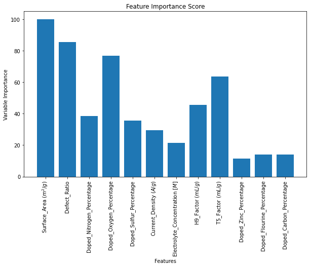

```
Stored 'rfopt' (list)
```

```python
# Normalize importance scores to percentages in respect to the largest diff
min_score = np.min(importance_score)
normalized_scores = [(score / min_score) * 100 for score in importance_score]

# Get the feature names from X_test as the x-axis labels
features = X_test.columns.tolist()

# Plot the histogram
plt.figure(figsize=(10, 6))
plt.bar(features, normalized_scores)
plt.xlabel('Features')
plt.ylabel('Variable Importance')
plt.title('Feature Importance Score')
plt.xticks(rotation=90)  # Rotate x-axis labels for better readability
plt.show()
%store rfopt
```

Accroding to the graph, the permuted surface area feature has the largest difference in OOB error, meaning that it is the most importance feature.

## (1.2) Multi-layer Perceptron (index)

### (1.2.1) (index)

```python
## EDIT THIS FUNCTION
def standardised(X, X_train_=None):
    """Standardise features.

    Parameters:
        X (np.array): Feature matrix.
        X_train_ (np.array): An optional feature matrix to compute the statistics
            from before applying it to X. If None, just use X to compute the statistics.

    Returns:
        X_std (np.array): Standardised feature matrix
    """
    if X_train_ is None:
        X_train_ = X

    mu = np.mean(X_train_, axis=0, keepdims=True)
    sigma = np.std(X_train_, axis=0, keepdims=True)
    X_std = (X - mu) / sigma
    return X_std
```

```python
# standardize train and test data because gradient descent could have numerical error
X_train_std = standardised(X_train.to_numpy())
X_test_std = standardised(X_test.to_numpy(), X_train_=X_train.to_numpy())
y_train_std = standardised(y_train.to_numpy())
y_test_std = standardised(y_test.to_numpy(), X_train_=y_train.to_numpy())
```

```python
## EDIT THIS FUNCTION
def dense(X, W, b):
    """Full-connected MLP layer.

    Parameters:
        X (np.ndarray): K x h_in array of inputs, where K is the batch size and h_in if the input features dimension.
        W (np.ndarray): h_out x h_in array for kernel matrix parametersm, where h_out is the output dimension.
        b (np.ndarray): Length h_out 1-D array for bias parameters

    Returns:
        a (np.ndarray): K x h_out array of pre-activations
    """
    a = np.vstack([W @ x + b for x in X])
    return a
```

```python
def tanhlog_activation(a):
    """tanhlog activation function.

    Parameters:
        a: K x h_out array of pre-activations

    Returns:
        h: K x h_out array of post-activations
    """
    # compute post-activations
    h = np.arctan(a)*np.log(abs(a) + 1)
    return h
 ## EDIT THIS FUNCTION
def grad_tanhlog_activation(a):
    """Gradient of Tanhlog activation function.

    Parameters:
        a: K x h_out array of pre-activations

    Returns:
        grad: K x h_out gradient array of post-activations
    """
    # compute gradient
    grad = np.log(abs(a) + 1)/(a**2 + 1) + (a* np.arctan(a))/(np.abs(a) + a**2)
    return grad
```

```python
# A lookup table for activation functions by their names.
activation_table = {
    "tanhlog": tanhlog_activation,
    # Identity function.
    "identity": lambda x: x
}

# A lookup table for gradient of activation functions by their names.
grad_activation_table = {
    "tanhlog": grad_tanhlog_activation,
    # Identity function gradient.
    "identity": lambda x: np.ones_like(x)
}


class MLP:
    """
    This class represents a Multi-Layer Perceptron (MLP), that we are going
    to use to encapsulate two components:
        1. layers: the sequence of layers, where each layer is stored in
            a dictionary in the format {"W": np.ndarray, "b": np.ndarray},
            where "W" points to the weights array, and "b" points to
            the bias vector.
        2. rng: a pseudo random number generator (RNG) initialised to generate
            the random weights in a reproducible manner between different
            runtime sessions.
    This class is also shipped with methods that perform essential operations
    with a MLP, including:
        - add_layers: which creates a new layer with specified dimensions.
        - predict: applies the MLP forward pass to make predictions and produces
            a computational graph for the forward pass that can be used to
            compute gradients using backpropagation algorithm.
        in addition to other light functions that return simple statistics about
        the MLP.
    """
    def __init__(self, seed=42):
        self.layers = []
        self.rng = np.random.default_rng(seed)

    def n_parameters(self):
        """Return the total number of parameters of weights and biases."""
        return sum(l["b"].size + l["W"].size for l in self.layers)

    def n_layers(self):
        """Return current number of MLP layers."""
        return len(self.layers)

    def layer_dim(self, index):
        """Retrieve the dimensions of the MLP layer at `index`."""
        return self.layers[index]["W"].shape

    def add_layer(self, in_dim, out_dim, activation="identity"):
        """Add fully connected layer to MLP.

        Parameters:
            in_dim (int): The output dimension of the layer.
            out_dim (int): The input dimension of the layer.
            activation (str): The activation function name.
        """
        # check if input-dimension matches output-dimension of previous layer
        if self.n_layers() > 0:
            last_out_dim, _ = self.layer_dim(-1)
            assert in_dim == last_out_dim, f"Input-dimension {in_dim} does not match output-dimension {last_out_dim} of previous layer."

        # the first layer, in our convention illustrated, does not apply activation on the input features X.
        if self.n_layers() == 0:
            assert activation == "identity", "Should not apply activations on the input features X, use Identity function for the first layer."


        # store each layer as a dictionary in the list, as shown in the
        # attached diagram.
        self.layers.append({
            # only for debugging.
            "index": len(self.layers),
            # apply Glorot initialisation for weights.
            "W": self.rng.normal(size=(out_dim, in_dim)) * np.sqrt(2. / (in_dim + out_dim)),
            # initialise bias vector with zeros.
            "b": np.zeros(out_dim), ## <-- SOLUTION
            # store the activation function (as string)
            "activation": activation
        })

    def predict(self, X):
        """Apply the forward pass on the input X and produce prediction and the
        forward computation graph.

        Parameters:
            X (np.ndarray): Feature matrix.

        Returns:
            (np.ndarray, List[Dict[str, np.ndarray]]): A tuple of the
            predictions and the computation graph as a sequence of intermediate
            values through the MLP, specifically each layer will have a corresponding
            intermediate values {"a": np.ndarray, "h": np.ndarray}, as shown in the
            attached diagram above.
        """
        # We assume that we work with a batch of examples (ndim==2).
        if X.ndim == 1:
            # If one example passed, add a dummy dimension for the batch.
            X = X.reshape(1, -1)

        # store pre- and post-activations in list
        forward_pass = [{"index": 0, "a": X, "h": X}]

        # iterate through hidden layers
        for k in range(1, len(self.layers)):
            # compute pre-activations
            a = dense(forward_pass[k - 1]["h"], self.layers[k - 1]["W"], self.layers[k - 1]["b"]) ## <-- SOLUTION
            activation = activation_table[self.layers[k]["activation"]] ## <-- SOLUTION
            forward_pass.append({"index": k, "a" : a, "h" : activation(a)}) ## <-- SOLUTION

        y_hat = dense(forward_pass[-1]["h"], self.layers[-1]["W"], self.layers[-1]["b"]) ## <-- SOLUTION
        # predicted target is output of last layer
        return y_hat, forward_pass
```

```python
def mse_loss(y_true, y_pred):
    """Compute MSE-loss

    Parameters:
        y_true: ground-truth array, with shape (K, )
        y_pred: predictions array, with shape (K, )

    Returns:
        loss (float): MSE-loss
    """
    assert y_true.size == y_pred.size, "Ground-truth and predictions have different dimensions."

    # Adjustment to avoid subtraction between (K,) and (1, K) arrays.
    y_true = y_true.reshape(y_pred.shape)


    return np.mean((y_true - y_pred)**2, keepdims=True)
```

```python
def grad_mse_loss(y_true, y_pred):
    """Compute gradient of MSE-loss

    Parameters:
        y_true: ground-truth values, shape: (K, ).
        y_pred: prediction values, shape: (K, ).

    Returns:
        grad (np.ndarray): Gradient of MSE-loss, shape: (K, ).
    """
    # Adjustment to avoid subtraction between (K,) and (1, K) arrays.
    y_true = y_true.reshape(y_pred.shape)

    return 2.0 * (y_pred - y_true) / y_true.size
```

```python
def backpropagate(layers, forward_pass, delta_output):
    """
    Apply the backpropagation algorithm to the MLP layers to compute the gradients starting from
    the output layer to the input layer, and starting the chain rule from the
    partial derivative of the loss function w.r.t the predictions $\hat{y}$. The

    Parameters:
        layers (List[Dict[str, np.ndarray]]): The MLP sequence of layers, as shown in the diagrams.
        forward_pass (List[Dict[str, np.ndarray]]): The forward pass intermediate values for
            each layer, representing a computation graph.
        delta_output (np.ndarray): the partial derivative of the loss function w.r.t the
            predictions $\hat{y}$, has the shape (K, 1), where K is the batch size.
    Returns:
        (List[Dict[str, np.ndarray]]): The computed gradient using a structure symmetric the layers, as shown
            in the diagrams.

    """
    # Create a list that will contain the gradients of all the layers.
    delta = delta_output

    assert len(layers) == len(forward_pass), "Number of layers is expected to match the number of forward pass layers"

    # Iterate on layers backwardly, from output to input.
    # Calculate gradients w.r.t. weights and biases of each level and store in list of dictionaries.
    gradients = []
    for layer, forward_computes in reversed(list(zip(layers, forward_pass))):
        assert forward_computes["index"] == layer["index"], "Mismatch in the index."

        h = forward_computes["h"]
        assert delta.shape[0] == h.shape[0], "Mismatch in the batch dimension."


        gradients.append({"W" : delta.T @ h,
                          "b" : delta.sum(axis=0)})

        # Update the delta for the next iteration
        grad_activation_f = grad_activation_table[layer["activation"]]
        grad_activation = grad_activation_f(forward_computes["a"])

        # Calculate the delta for the backward layer.
        delta = np.stack([np.diag(gi) @ layer["W"].T @ di
                           for (gi, di) in zip(grad_activation, delta)])


    # Return now ordered list matching the layers.
    return list(reversed(gradients))
```

```python
def sgd_step(X, y, mlp, learning_rate = 1e-3):
    """
    Apply a stochastic gradient descent step using the sampled batch.
    Parameters:
        X (np.ndarray): The input features array batch, with dimension (K, D).
        y (np.ndarray): The ground-truth of the batch, with dimension (K, 1).
        learning_rate (float): The learning rate multiplier for the update steps in SGD.
    Returns:
        (List[Dict[str, np.ndarray]]): The updated layers after applying SGD.
    """
    # Compute the forward pass.
    y_hat, forward_pass = mlp.predict(X) ## <-- SOLUTION.

    # Compute the partial derivative of the loss w.r.t. to predictions `y_hat`.
    delta_output = grad_mse_loss(y, y_hat) ## <-- SOLUTION

    # Apply backpropagation algorithm to compute the gradients of the MLP parameters.
    gradients = backpropagate(mlp.layers, forward_pass, delta_output)  ## <-- SOLUTION.

    # mlp.layers and gradients are symmetric, as shown in the figure.
    updated_layers = []
    for layer, grad in zip(mlp.layers, gradients):
        W = layer["W"] - learning_rate * grad["W"] ## <-- SOLUTION.
        b = layer["b"] - learning_rate * grad["b"] ## <-- SOLUTION.
        updated_layers.append({"W": W, "b": b,
                               # keep the activation function.
                               "activation": layer["activation"],
                               # We use the index for asserts and debugging purposes only.
                               "index": layer["index"]})
    return updated_layers
```

```python
def r2_score(y, y_hat):
    """R^2 score to assess regression performance."""

    # Adjustment to avoid subtraction between (K,) and (1, K) arrays.
    y = y.reshape(y_hat.shape)
    y_bar = y.mean()

    ss_tot = ((y - y_bar)**2).sum()
    ss_res = ((y - y_hat)**2).sum()
    return 1 - (ss_res/ss_tot)
```

```python
from tqdm.notebook import tqdm # just a fancy progress bar
```

```python
def sgd(X_train, y_train, X_test, y_test, mlp, learning_rate = 5e-5,
        n_epochs=300, minibatchsize=8, seed=8):
    """
    Run the Stochastic Gradient Descent (SGD) algorithm to optimise the parameters of MLP model to fit it on
    the training data using MSE loss.

    Parameters:
        X_train (np.ndarray): The training data features, with shape (|D_train|, D).
        y_train (np.ndarray): The training data ground-truth, with shape (|D_train|, 1).
        X_test (np.ndarray): The testing data features, with shape (|D_test|, D).
        y_test (np.ndarray): The testing data ground-truth, with shape (|D_test|, 1).
        mlp (MLP): The MLP object enacpsulating the MLP model.
        learning_rate (float): The learning_rate multiplier used in updating the parameters at each iteration.
        n_epochs (int): The number of training cycles that each covers the entire training examples.
        minibatchsize (int): The batch size used in each SGD step.
        seed (int): A seed for the RNG to ensure reproducibility across runtime sessions.
    """

    # get random number generator
    rng = np.random.default_rng(seed)

    # compute number of iterations per epoch
    n_iterations = int(len(y_train) / minibatchsize)

    # store losses
    losses_train = []
    losses_test = []

    epochs_bar = tqdm(range(n_epochs))
    for i in epochs_bar:

        # shuffle data
        p = rng.permutation(len(y_train))
        X_train_shuffled = X_train[p]
        y_train_shuffled = y_train[p]

        for j in range(n_iterations):
            # get batch
            X_batch = X_train_shuffled[j*minibatchsize : (j+1)*minibatchsize]
            y_batch = y_train_shuffled[j*minibatchsize : (j+1)*minibatchsize]
            # apply sgd step
            updated_layers = sgd_step(X_batch, y_batch, mlp, learning_rate)

            # update weights and biases of MLP
            mlp.layers = updated_layers

        # compute loss at the end of each epoch
        y_hat_train, _ = mlp.predict(X_train)
        losses_train.append(mse_loss(y_train, y_hat_train).squeeze())
        y_hat_test, _ = mlp.predict(X_test)
        losses_test.append(mse_loss(y_test, y_hat_test).squeeze())
        epochs_bar.set_description(f'train_loss: {losses_train[-1]:.2f}, '
                                   f'test_loss: {losses_test[-1]:.2f}, '
                                   f'train_R^2: {r2_score(y_train, y_hat_train):.2f} '
                                   f'test_R^2: {r2_score(y_test, y_hat_test):.2f} ')
    return mlp, losses_train, losses_test
```

```python
mlp = MLP(seed=2)
mlp.add_layer(12, 50)
mlp.add_layer(50, 50, "tanhlog")
mlp.add_layer(50, 50, "tanhlog")
mlp.add_layer(50, 1, "identity") # this used because this function has image equal real and regression which is what we want in this case
print("Number of layers:", mlp.n_layers())
print("Number of trainable parameters:", mlp.n_parameters())

n_epochs = 300
mlp, losses_train, losses_test = sgd(X_train_std, y_train_std, X_test_std, y_test_std,
                                     mlp, learning_rate = 5e-5,
                                     n_epochs=n_epochs,
                                     minibatchsize=8)
```

```
Number of layers: 4
Number of trainable parameters: 5801
```

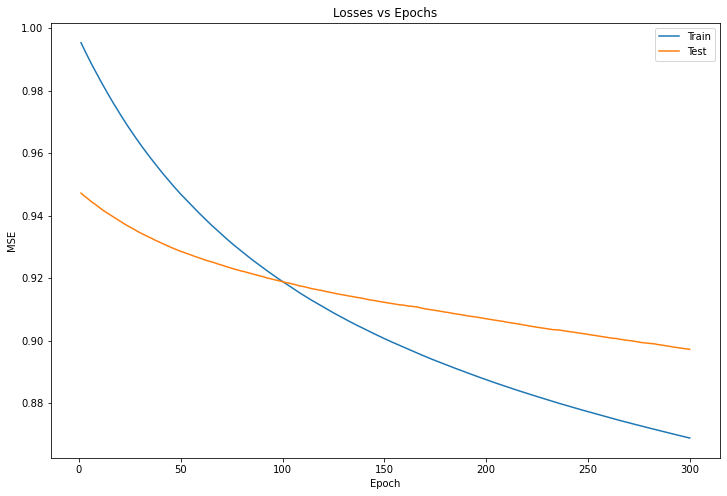

```python
# plot training progress
fig, ax = plt.subplots(figsize=(12, 8))
ax.plot(np.arange(1,n_epochs+1),losses_train, label="Train")
ax.plot(np.arange(1,n_epochs+1),losses_test, label="Test")
ax.set(title="Losses vs Epochs", xlabel = "Epoch", ylabel = "MSE")
ax.legend()
plt.show()
```

The MSE error of the neural network is 0.9(after normalzied), while the R^2 error is 0.1, the generalization power of the model is not good

### (1.2.2) (index)

```python
def sgd_with_mv(X_train, y_train, X_test, y_test, mlp, learning_rate = 1e-3,
        n_epochs=10, minibatchsize=1, seed=42, beta = 0.4):
    """
    Run the Stochastic Gradient Descent with momentum (SGD with mv) algorithm to optimise the parameters of MLP model to fit it on
    the training data using MSE loss.

    Parameters:
        X_train (np.ndarray): The training data features, with shape (|D_train|, D).
        y_train (np.ndarray): The training data ground-truth, with shape (|D_train|, 1).
        X_test (np.ndarray): The testing data features, with shape (|D_test|, D).
        y_test (np.ndarray): The testing data ground-truth, with shape (|D_test|, 1).
        mlp (MLP): The MLP object enacpsulating the MLP model.
        learning_rate (float): The learning_rate multiplier used in updating the parameters at each iteration.
        n_epochs (int): The number of training cycles that each covers the entire training examples.
        minibatchsize (int): The batch size used in each SGD step.
        seed (int): A seed for the RNG to ensure reproducibility across runtime sessions.
        bet(float): momentum parameter
    """

    # get random number generator
    rng = np.random.default_rng(seed)

    # compute number of iterations per epoch
    n_iterations = int(len(y_train) / minibatchsize)

    # store losses
    losses_train = []
    losses_test = []

    epochs_bar = tqdm(range(n_epochs))
    for i in epochs_bar:

        # shuffle data
        p = rng.permutation(len(y_train))
        X_train_shuffled = X_train[p]
        y_train_shuffled = y_train[p]

        for j in range(n_iterations):
            # get batch
            X_batch = X_train_shuffled[j*minibatchsize : (j+1)*minibatchsize]
            y_batch = y_train_shuffled[j*minibatchsize : (j+1)*minibatchsize]
            # apply sgd step
            updated_layers = sgd_step_mv(X_batch, y_batch, mlp, learning_rate)

            # update weights and biases of MLP
            mlp.layers = updated_layers

        # compute loss at the end of each epoch
        y_hat_train, _ = mlp.predict(X_train)
        losses_train.append(mse_loss(y_train, y_hat_train).squeeze())
        y_hat_test, _ = mlp.predict(X_test)
        losses_test.append(mse_loss(y_test, y_hat_test).squeeze())
        epochs_bar.set_description(f'train_loss: {losses_train[-1]:.2f}, '
                                   f'test_loss: {losses_test[-1]:.2f}, '
                                   f'train_R^2: {r2_score(y_train, y_hat_train):.2f} '
                                   f'test_R^2: {r2_score(y_test, y_hat_test):.2f} ')
    return mlp, losses_train, losses_test
```

```python
def sgd_step_mv(X, y, mlp, learning_rate = 1e-3, beta = 0.4):
    """
    Apply a stochastic gradient descent with momentum step using the sampled batch.
    Parameters:
        X (np.ndarray): The input features array batch, with dimension (K, D).
        y (np.ndarray): The ground-truth of the batch, with dimension (K, 1).
        learning_rate (float): The learning rate multiplier for the update steps in SGD with mv.
        beta(float): momentum parameter
    Returns:
        (List[Dict[str, np.ndarray]]): The updated layers after applying SGD with mv.
    """
    # Compute the forward pass.
    y_hat, forward_pass = mlp.predict(X)

    # Compute the partial derivative of the loss w.r.t. to predictions `y_hat`.
    delta_output = grad_mse_loss(y, y_hat)

    # Apply backpropagation algorithm to compute the gradients of the MLP parameters.
    gradients = backpropagate(mlp.layers, forward_pass, delta_output)

    # mlp.layers and gradients are symmetric, as shown in the figure.
    #create momentum dictionary to store the present moentum
    mv = [{t: np.zeros_like(layer[t]) for t in ["W", "b"]} for layer in mlp.layers]
    updated_layers = []
    for layer, grad, p  in zip(mlp.layers, gradients, mv):
        #calculate the new direction of the decent
        p["W"] = beta * p["W"] + learning_rate * grad["W"]
        p["b"] = beta * p["b"] + learning_rate * grad["b"]
        #update the bias and weight
        W = layer["W"] - p["W"]
        b = layer["b"] - p["b"]
        updated_layers.append({"W": W, "b": b,
                               # keep the activation function.
                               "activation": layer["activation"],
                               # We use the index for asserts and debugging purposes only.
                               "index": layer["index"]})
    return updated_layers
```

```python
mlpmv = MLP(seed=31)
mlpmv.add_layer(12, 50)
mlpmv.add_layer(50, 50, "tanhlog")
mlpmv.add_layer(50, 50, "tanhlog")
mlpmv.add_layer(50, 1, "identity") # this used because this function has image equal real which is what we want in this case
print("Number of layers:", mlp.n_layers())
print("Number of trainable parameters:", mlp.n_parameters())

n_epochs = 300
mlp, losses_train, losses_test = sgd_with_mv(X_train_std, y_train_std, X_test_std, y_test_std,
                                     mlp, learning_rate = 5e-5,
                                     n_epochs=n_epochs,
                                     minibatchsize=8, beta=0.4)
```

```
Number of layers: 4
Number of trainable parameters: 5801
```

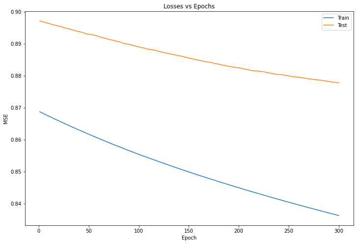

```python
# plot training progress
fig, ax = plt.subplots(figsize=(12, 8))
ax.plot(np.arange(1,n_epochs+1),losses_train, label="Train")
ax.plot(np.arange(1,n_epochs+1),losses_test, label="Test")
ax.set(title="Losses vs Epochs", xlabel = "Epoch", ylabel = "MSE")
ax.legend()
plt.show()
```

### (1.2.3) (index)

MLP is often harder to interpret comparing to simpler non-linear model, as there are many layer and nodes, and it is hard for human to interpret, while simplier non-linear model are much more easier to interpret as they have simpler structure. But MLP is more suitable to deal with complex and a large ammount of data comparing to simpler non-linear model, as there are a lot of system that can't be described by simpler non-linear model and MLP can have very complied non-linear relationship

```python
#setting up data
X_train_pi = X_train.to_numpy()
X_test_pi = X_test.to_numpy()
y_train_pi = y_train.to_numpy()
y_test_pi = y_test.to_numpy()
```

[output not shown]

```python
#create a list of all possible quadratic term
quadratic_indices = [(i, j) for i in range(12) for j in range(12) if i >= j]

def make_quad_term(X_train, a, b):
    tmp = np.zeros(X_train.shape[0])
    for i in range(X_train.shape[0]):
        tmp[i] = X_train[i, a] * X_train[i, b]
    return tmp
def make_quad_array(X_train, quadratic_indices):
    tmp = X_train.copy()
    for idx in quadratic_indices:
         tmp = np.hstack((tmp, make_quad_term(X_train, idx[0], idx[1]).reshape(-1, 1)))
    return tmp

#create a list with the all the feature and their quadratic term
X_train_pi_quad = make_quad_array(X_train_pi, quadratic_indices)
X_test_pi_quad = make_quad_array(X_test_pi, quadratic_indices)
```

```python
## EDIT THIS FUNCTION
def ridge_estimate(X, y, penalty):

    # X: N x D matrix of training inputs
    # y: N x 1 vector of training targets/observations
    # returns: maximum likelihood parameters (D x 1)

    N, D = X.shape
    X_aug = np.hstack([np.ones((N,1)), X]) # augmented training inputs of size N x (D+1)
    N_aug, D_aug = X_aug.shape
    I = np.identity(D_aug)
    I[0] = 0.0 # penalty excludes the bias term.
    beta_ridge = np.linalg.solve(X_aug.T @ X_aug + penalty * I, X_aug.T @ y)
    return beta_ridge
```

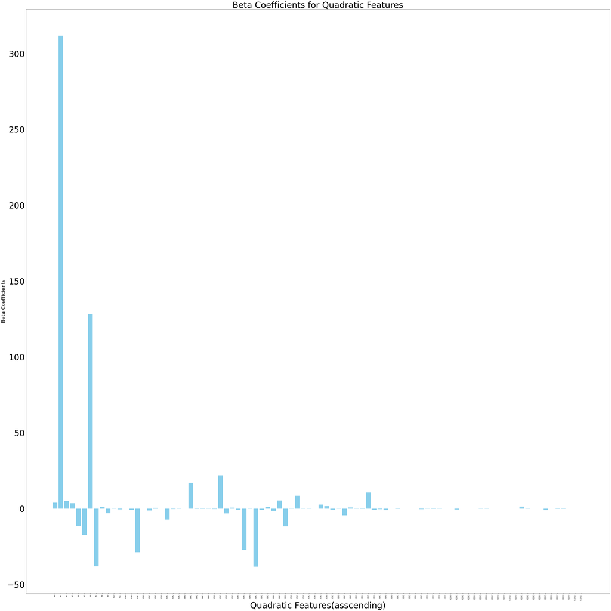

```python
# case penalty_term = 0.0001
penalty_term = 0.0001
beta_coef = ridge_estimate(X_train_pi_quad, y_train_pi, penalty_term)
#create the x-axis of the plot
quad_feature = ["X" + str(i) for i in range(12)] + ["X" + str(idx[0]) + "X" + str(idx[1]) for idx in quadratic_indices]

plt.figure(figsize=(50, 50))
plt.bar(quad_feature, beta_coef[1:], color='skyblue')
plt.xlabel('Quadratic Features(asscending)', fontsize = 50 )
plt.ylabel('Beta Coefficients', fontsize = 30)
plt.title('Beta Coefficients for Quadratic Features', fontsize = 50)
plt.xticks(rotation=90)
plt.yticks(fontsize = 50)
plt.tight_layout()
## please note that as there are more than 100 value in the x-axis, it can't be shown very prettily.
```

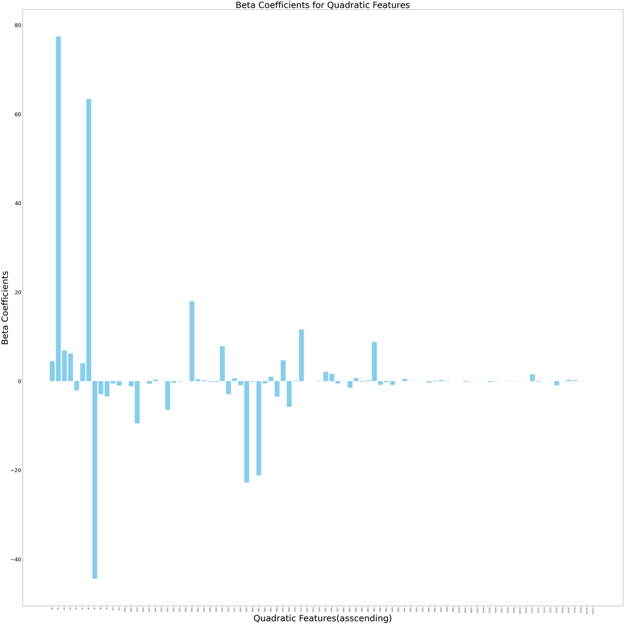

```python
# case penalty_term=1
penalty_term = 1
beta_coef = ridge_estimate(X_train_pi_quad, y_train_pi, penalty_term)

plt.figure(figsize=(50, 50))
plt.bar(quad_feature, beta_coef[1:], color='skyblue')
plt.xlabel('Quadratic Features(asscending)', fontsize = 50 )
plt.ylabel('Beta Coefficients', fontsize = 50)
plt.title('Beta Coefficients for Quadratic Features', fontsize = 50)
plt.xticks(rotation=90)
plt.yticks(fontsize = 30)
plt.tight_layout()
```

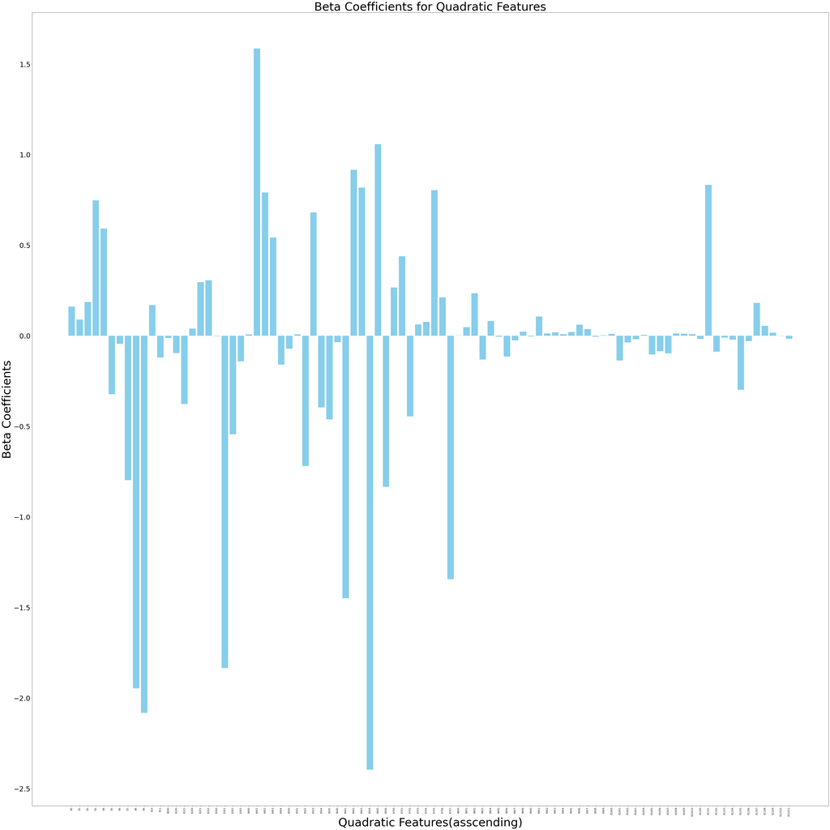

```python
#case penalty_term = 1000
penalty_term = 1000
beta_coef = ridge_estimate(X_train_pi_quad, y_train_pi, penalty_term)

plt.figure(figsize=(50, 50))
plt.bar(quad_feature, beta_coef[1:], color='skyblue')
plt.xlabel('Quadratic Features(asscending)', fontsize = 50 )
plt.ylabel('Beta Coefficients', fontsize = 50)
plt.title('Beta Coefficients for Quadratic Features', fontsize = 50)
plt.xticks(rotation=90)
plt.yticks(fontsize = 30)
plt.tight_layout()
```

```python
def LR_score(X_train, y_train, X_test, y_test, penalty_term):
    "Return MSE score for linear regression."
    beta_coef = ridge_estimate(X_train, y_train, penalty_term)
    X_test_aug = np.hstack([np.ones((X_test.shape[0],1)), X_test])
    y_pred = X_test_aug @ beta_coef
    score = np.mean((y_pred - y_test) ** 2)
    return score
```

```python
def R_square_er_LR(y_test, y_pred):
    "Return the R_square error for Linear Regression."
    R_squared = 1 - np.sum((y_test - y_pred)**2) / np.sum((y_test - np.mean(y_test))**2)
    return(R_squared)
```

```python
# EDIT THIS FUNCTION
def cross_validation_score_LR(X_train, y_train, folds, penalty_term):
  "return cross_validation_score of linear regression"
  scores = []
  for i in range(len(folds)):
    val_indexes = folds[i]
    train_indexes = list(set(range(y_train.shape[0])) - set(val_indexes))
    X_train_i = X_train[train_indexes, :]
    y_train_i = y_train[train_indexes]

    X_test_i = X_train[val_indexes, :]
    y_test_i = y_train[val_indexes]


    score_i = LR_score(X_train_i, y_train_i, X_test_i, y_test_i, penalty_term)
    scores.append(score_i)

  # Return the average score
  return np.sum(scores) / len(scores) # <- SOLUTION
```

```python
score_min = np.inf
best_lambda = 0
penalty_term = np.arange(0.1, 200.1, 0.1) #testing from 0.1 to 200 increase by 0.1 each time
LR_MSE_score = []

#finding the best penalty term
for i in penalty_term:
    tmp = cross_validation_score_LR(X_train_pi_quad, y_train_pi, folds_indexes, i)
    LR_MSE_score.append(tmp)
    if tmp < score_min:
        score_min = tmp
        best_lambda = i

beta_coef = ridge_estimate(X_train_pi_quad, y_train_pi, best_lambda)
X_test_aug = np.hstack([np.ones((X_test_pi_quad.shape[0], 1)), X_test_pi_quad])
y_pred = X_test_aug @ beta_coef

print('The best penalty term is', best_lambda)
print('The MSE score of the best peanly term is', LR_score(X_train_pi_quad, y_train_pi, X_test_pi_quad, y_test_pi, best_lambda))
print('The R^2 error of the best penaly term is', R_square_er_LR(y_test_pi, y_pred))
```

```
The best penalty term is 117.5
The MSE score of the best peanly term is 5116.440414377734
The R^2 error of the best penaly term is 0.2250278652217168
```

```python
##linear regression with no quadratic term and with no ridge term
print('the MSE score of Linear Regression with no quadratic term and no ridge term is', LR_score(X_train_pi, y_train_pi, X_test_pi, y_test_pi, 0))

## finding the best ridge constant for linear regression model with no quadratic term
score_min = np.inf
best_lambda = 0
penalty_term = np.arange(0.1, 200.1, 0.1)
LR_MSE_score = []
for i in penalty_term:
    tmp = cross_validation_score_LR(X_train_pi, y_train_pi, folds_indexes, i)
    LR_MSE_score.append(tmp)
    if tmp < score_min:
        score_min = tmp
        best_lambda = i

#creating y_pred for no ridge term
beta_coef = ridge_estimate(X_train_pi, y_train_pi, 0)
X_test_aug = np.hstack([np.ones((X_test_pi.shape[0], 1)), X_test_pi])
y_pred = X_test_aug @ beta_coef
print('The R^2 error of the best penaly term is', R_square_er_LR(y_test_pi, y_pred))

#creating y_pred for best ridge term
beta_coef = ridge_estimate(X_train_pi, y_train_pi, best_lambda)
X_test_aug = np.hstack([np.ones((X_test_pi.shape[0], 1)), X_test_pi])
y_pred = X_test_aug @ beta_coef

print('The best penalty term is', best_lambda)
print('The MSE score of the best peanly term is', LR_score(X_train_pi, y_train_pi, X_test_pi, y_test_pi, best_lambda))
print('The R^2 error of the best penaly term is', R_square_er_LR(y_test_pi, y_pred))
```

```
the MSE score of Linear Regression with no quadratic term and no ridge term is 5794.722718697767
The R^2 error of the best penaly term is 0.12229044568994674
The best penalty term is 8.5
The MSE score of the best peanly term is 5775.168630835368
The R^2 error of the best penaly term is 0.1252522456889814
```

As we can see from the MSE and R^2 result the linear regression with quadratic terms are cleary having better generative rsult then linear regression with no quadratic term, as the R^2 error of the piror case is significantly bigger than the R^2 error of the posterior case and the MSE is slighlty smaller. As for the linear regression with no quadratic term, we can see that adding a ridge constant term doesn't improve the score a lot, as both the MSE and R^2 score is around the same.

# (2) Task 2: Classification (index)

## (2.1) k-Nearest Neighbours (index)

### (2.1.1) (index)

```python
def std_except_seven(X_train):
    "A function that standardize the data, EXCEPT the location column(column 7)"
    seven_col = X_train.iloc[:, 7]
    X_train_wo_seven = X_train.drop(X_train.columns[7], axis = 1)
    X_train_wo_seven = standardise(X_train_wo_seven)
    ## Add the location column as the last column of the matrix
    Ans = pd.concat([X_train_wo_seven, seven_col], axis = 1)
    return Ans
```

```python
brain_test_data = pd.read_csv('C:\\Users\\sam\\imperial\\Year3\\Data sciecne\\CW1\\brain_cancer_test.csv')
brain_sample_data = pd.read_csv('C:\\Users\\sam\\imperial\\Year3\\Data sciecne\\CW1\\brain_cancer_samples.csv')

Pt = np.random.permutation(brain_test_data.shape[0])
Ps = np.random.permutation(brain_sample_data.shape[0])


## shuffling the rows in X and y
brain_test_data = brain_test_data.iloc[Pt]
brain_sample_data = brain_sample_data.iloc[Ps]

## we ignore the first column of the data because patient ID has no correlation with the tumor.
X_brain_test = brain_test_data.iloc[:, 1:-1]
y_brain_test = brain_test_data.iloc[:,-1]
X_brain_train = brain_sample_data.iloc[:, 1:-1]
y_brain_train = brain_sample_data.iloc[:, -1]
```

```python
def euclidian_distance(p, q):
    "calculate the distance between two data point"
    dif = p - q
    ## we deal with the special case (the location column) using the hamming distance method
    location_column = dif[:, -1]
    non_zero_indices = location_column != 0
    location_column[non_zero_indices] = 1
    dif[:, -1] = location_column
    return np.sqrt(np.sum((dif)**2, axis=1))
```

```python
## EDIT THIS FUNCTION
def k_neighbours(X_train, X_test, k=5, return_distance=False):
  n_neighbours = k
  dist = []
  neigh_ind = []

  # compute distance from each point x_test in X_test to all points in X_train (hint: use python's list comprehension)
  point_dist = [euclidian_distance(x_test, X_train) for x_test in X_test] ## <-- SOLUTION

  # determine which k training points are closest to each test point
  for row in point_dist:
      enum_neigh = enumerate(row)
      sorted_neigh = sorted(enum_neigh, key=lambda x: x[1])[:k]

      ind_list = [tup[0] for tup in sorted_neigh]
      dist_list = [tup[1] for tup in sorted_neigh]

      dist.append(dist_list)
      neigh_ind.append(ind_list)

  # return distances together with indices of k nearest neighbours
  if return_distance:
      return np.array(dist), np.array(neigh_ind)

  return np.array(neigh_ind)
```

```python
## EDIT THIS FUNCTION
def KNN_predict(X_train, y_train, X_test, k=5):
  # each of the k neighbours contributes equally to the classification of any data point in X_test
    neighbours = k_neighbours(X_train, X_test, k=k)
  # count number of occurences of label with np.bincount and choose the label that has most with np.argmax
    y_pred = np.array([np.argmax(np.bincount(y_train[neighbour])) for neighbour in neighbours])

    return y_pred
```

```python
#prepare folds_indexes for cross validation
folds_indexes = np.split(np.arange(len(y_brain_train)), 5)
folds_indexes
```

```
[array([ 0,  1,  2,  3,  4,  5,  6,  7,  8,  9, 10, 11, 12, 13, 14, 15, 16,
        17, 18, 19, 20, 21, 22, 23, 24, 25, 26, 27, 28]),
 array([29, 30, 31, 32, 33, 34, 35, 36, 37, 38, 39, 40, 41, 42, 43, 44, 45,
        46, 47, 48, 49, 50, 51, 52, 53, 54, 55, 56, 57]),
 array([58, 59, 60, 61, 62, 63, 64, 65, 66, 67, 68, 69, 70, 71, 72, 73, 74,
        75, 76, 77, 78, 79, 80, 81, 82, 83, 84, 85, 86]),
 array([ 87,  88,  89,  90,  91,  92,  93,  94,  95,  96,  97,  98,  99,
        100, 101, 102, 103, 104, 105, 106, 107, 108, 109, 110, 111, 112,
        113, 114, 115]),
 array([116, 117, 118, 119, 120, 121, 122, 123, 124, 125, 126, 127, 128,
        129, 130, 131, 132, 133, 134, 135, 136, 137, 138, 139, 140, 141,
        142, 143, 144])]
```

```python
def micscore(X_train, y_train, X_test, y_test, k=5):
    "Return micro precision"
    y_pred = KNN_predict(X_train, y_train, X_test, k=k) ## <-- SOLUTION
    conj_table = np.zeros((3, 3))
    for i in range(len(y_pred)):
        conj_table[y_test[i], y_pred[i]] += 1
    acc = np.sum(np.diag(conj_table)) / np.sum(conj_table)
    return acc
```

```python
def cross_validation_score(X_train, y_train, folds, k):
    "Return cross validation score using KNN"
    scores = []
    for i in range(len(folds)):
        val_indexes = folds[i]
        train_indexes = list(set(range(y_train.shape[0])) - set(val_indexes))

        X_train_i = X_train[train_indexes, :]
        y_train_i = y_train[train_indexes]


        X_val_i = X_train[val_indexes, :]
        y_val_i = y_train[val_indexes]

        score_i = micscore(X_train_i, y_train_i, X_val_i, y_val_i, k=k)
        scores.append(score_i)

        # Return the average score
    return sum(scores) / len(scores)
```

```python
def choose_best_k(X_train, y_train, folds, k_range):
    "return the best K for KNN"
    k_scores = np.zeros((len(k_range),))

    for i, k in enumerate(k_range):
        k_scores[i] = cross_validation_score(X_train, y_train, folds, k)
        print(f'CV_ACC@k={k}: {k_scores[i]:.3f}')

    best_k_index = np.argmax(k_scores)
    return k_range[best_k_index]
```

```python
best_k = choose_best_k(X_brain_train.to_numpy(), y_brain_train.to_numpy(), folds_indexes, np.arange(1, 31))
print('the best k is ',best_k)
```

```
CV_ACC@k=1: 0.497
CV_ACC@k=2: 0.462
CV_ACC@k=3: 0.531
CV_ACC@k=4: 0.579
CV_ACC@k=5: 0.572
CV_ACC@k=6: 0.600
CV_ACC@k=7: 0.566
CV_ACC@k=8: 0.579
CV_ACC@k=9: 0.559
CV_ACC@k=10: 0.524
CV_ACC@k=11: 0.531
CV_ACC@k=12: 0.510
CV_ACC@k=13: 0.497
CV_ACC@k=14: 0.476
CV_ACC@k=15: 0.490
CV_ACC@k=16: 0.497
CV_ACC@k=17: 0.497
CV_ACC@k=18: 0.490
CV_ACC@k=19: 0.510
CV_ACC@k=20: 0.483
CV_ACC@k=21: 0.497
CV_ACC@k=22: 0.469
CV_ACC@k=23: 0.497
CV_ACC@k=24: 0.503
CV_ACC@k=25: 0.497
CV_ACC@k=26: 0.497
CV_ACC@k=27: 0.510
CV_ACC@k=28: 0.483
CV_ACC@k=29: 0.483
CV_ACC@k=30: 0.469
the best k is  6
```

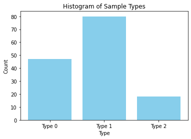

```python
# Counting occurrences of each type
unique_types, counts = np.unique(y_brain_train, return_counts=True)

# Creating the histogram
plt.bar(unique_types, counts, color='skyblue')
plt.xlabel('Type')
plt.ylabel('Count')
plt.title('Histogram of Sample Types')
plt.xticks(np.arange(3), labels=['Type 0', 'Type 1', 'Type 2'])

plt.show()
```

Clearly Type 2 is underrepesented

```python
def evaluate_metric(conj_table):
    "Return the evaluate metric m"
    precision = [conj_table[i, i] / np.sum(conj_table[: , i]) for i in range(3)]
    mac_pre = np.sum(precision)/3
    mic_pre = np.sum(np.diag(conj_table))/np.sum(conj_table)
    wei_pre = np.dot(precision, [ np.sum(conj_table[i, :]) for i in range(3)])/np.sum(conj_table)

    accuracy = np.zeros(3)

    for i in range(3):
         accuracy[i] = np.sum([conj_table[j, k] for j in range(3) for k in range(3) if (j != i and k != i) or (j == i and k == i)])
    accuracy = accuracy/np.sum(conj_table)
    mac_acc = np.sum(accuracy)/3
    mic_acc = mac_acc
    wei_acc = np.dot(accuracy, [ np.sum(conj_table[i, :]) for i in range(3)])/np.sum(conj_table)

    return (mac_pre, mic_pre, wei_pre, mac_acc, mic_acc, wei_acc)

conj_score = np.array([ i for i in evaluate_metric(conj_table)])
print('the macro precision is', conj_score[0])
print('the micro precision is', conj_score[1])
print('the weighted avg precsision is', conj_score[2])
print('the macro accuracy is', conj_score[3])
print('the micro accuacy is', conj_score[4])
print('the weighted accuracy is', conj_score[5])
```

```
the macro precision is 0.774891774891775
the micro precision is 0.6833333333333333
the weighted avg precsision is 0.7072510822510822
the macro accuracy is 0.7888888888888889
the micro accuacy is 0.7888888888888889
the weighted accuracy is 0.7355555555555555
```

I think that this KNN doesn't classify corrently predicts the minority class, despite a relatively high accuracy and macro precision, it has a rather low micro precision, and weighted precision, accuracy. As class 2 is underpresented, accroding to tha algorithm of KNN, it is hard for the KNN alogirhtm to find enough class 2 sample for it to classify, that's why I guess, the KNN algorithm can predict the class 2 quite (accurately no false positive), but in actual case it will often misjudge class to other class, that's why when we are counting the micro precision it has rather no accuracy as a lot of class 2 is being miss judge, while the macro precision is being skewed by the very high precision of class 2.

### (2.1.2) (index)

```python
## EDIT THIS FUNCTION
def adjusted_predict(X_train, y_train, X_test, k=5):
    "return the adjusted prediction"
  # each of the k neighbours contributes accroidng to the distance to the classification of any data point in X_test
    dist, neighbours = k_neighbours(X_train, X_test, k=k, return_distance=True)

    eps = 1e-20
    weight = 1/(eps + dist)**2
    # we adjusted the weight accroiding to the distance between the point and the point we want to know, as we have the assumption that the closer it is the highly likely it is in that class
    # count number of occurences of label with np.bincount and choose the label that has most with np.argmax (hint: use python's list comprehension)
    weighted_labels = np.array([np.bincount(y_train[neighbour], weights=w, minlength=np.max(y_train) + 1) for w, neighbour in zip(weight, neighbours)])

    y_pred = np.argmax(weighted_labels, axis=1)
    return y_pred
```

```python
def adjusted_conj_table(X_train, y_train, X_test, y_test, k=5):
    #conj_table
    y_pred = adjusted_predict(X_train, y_train, X_test, k=k) ## <-- SOLUTION
    conj_table = np.zeros((3, 3))
    for i in range(len(y_pred)):
        conj_table[y_test[i], y_pred[i]] += 1
    return conj_table
adjusted_conj_table = adjusted_conj_table(X_brain_train.to_numpy(), y_brain_train.to_numpy(), X_brain_test.to_numpy(), y_brain_test.to_numpy(), best_k)

conj_score = np.array([ i for i in evaluate_metric(adjusted_conj_table)])
print('the macro precision is', conj_score[0])
print('the micro precision is', conj_score[1])
print('the weighted avg precsision is', conj_score[2])
print('the macro accuracy is', conj_score[3])
print('the micro accuacy is', conj_score[4])
print('the weighted accuracy is', conj_score[5])
```

```
the macro precision is 0.7976190476190476
the micro precision is 0.75
the weighted avg precsision is 0.7470238095238095
the macro accuracy is 0.8333333333333334
the micro accuacy is 0.8333333333333334
the weighted accuracy is 0.7822222222222222
```

As we can see the for every evalualte metric it is improved, it is because we consider the case that when a node is closer it is more probably that it has the same value than the nodes that are further.

### (2.1.3) (index)

```python
def first_knn_classification(X_train, y_train, X_test, k = 5):
    "First KNN layer classification, just to divde the data into class(2,1) and class(0)"
    adj_y_train =  [y_train == 0]
    adj_y_train = 1 - np.array(adj_y_train).astype(int)
    adj_y_train = adj_y_train.flatten()
    prediction = adjusted_predict(X_train, adj_y_train, X_test, k=k)

    return prediction
```

```python
def second_knn_classification(X_train, y_train, X_test, k = 5):
    "Second KNN layer classifcation, in the class(2, 1), we classify between 1 and 2"
    prediction = np.zeros(len(X_test))
    first_prediction = first_knn_classification(X_train, y_train, X_test, k = k)
    one_indices = np.where(first_prediction == 1)[0]
    train_one_indices = np.where(y_train != 0)[0]
    second_prediction = adjusted_predict(X_train[train_one_indices], y_train[train_one_indices], X_test[one_indices], k=k)
    cnt = -1
    # added the second prediction with the first prediction
    for i in range(len(X_test)):
        if first_prediction[i] !=0:
            cnt += 1
            prediction[i] = second_prediction[cnt]
    prediction = prediction.astype(int)
    return prediction
```

```python
def adjusted_two_layer_conj_table(X_train, y_train, X_test, y_test, k=5):
    "conj_table for 2 step KNN"
    y_pred = second_knn_classification(X_train, y_train, X_test, k=k) ## <-- SOLUTION
    conj_table = np.zeros((3, 3))
    for i in range(len(y_pred)):
        conj_table[y_test[i], y_pred[i]] += 1
    return conj_table

tmp = adjusted_two_layer_conj_table(X_brain_train.to_numpy(), y_brain_train.to_numpy(), X_brain_test.to_numpy(), y_brain_test.to_numpy(), k=best_k)
conj_score = np.array([ i for i in evaluate_metric(tmp)])
print('the macro precision is', conj_score[0])
print('the micro precision is', conj_score[1])
print('the weighted avg precsision is', conj_score[2])
print('the macro accuracy is', conj_score[3])
print('the micro accuacy is', conj_score[4])
print('the weighted accuracy is', conj_score[5])
```

```
the macro precision is 0.7976190476190476
the micro precision is 0.75
the weighted avg precsision is 0.7470238095238095
the macro accuracy is 0.8333333333333334
the micro accuacy is 0.8333333333333334
the weighted accuracy is 0.7822222222222222
```

The 2 step KNN is clearly doing better than the only one step KNN, but it perform bascially the same compaing with the adjsuted KNN, I guess this is because, the second class is so underrepresneted, even if we divide the class to two then do KNN on class(1,2) it is still easy for the KNN to misjduge data from class 2 to other class. Not to mention, an around 80% of accuracy and precision is hard to improve.

## (2.2) Logistic regression vs kernel logistic regression (index)

### (2.2.1) (index)

```python
def logistic(z):
    return 1. / (1. + np.exp(-z))
```

```python
def predict_log(X, beta):
    y_log = logistic(X @ beta)
    return y_log.squeeze()
```

```python
def initialise(size):
    """
    Argument:
    size: Size of the parameter vector beta

    Returns:
    beta: Initialised vector of shape (size, 1)

    """

    beta = np.zeros((size, 1))

    return beta
```

```python
def propagate(X, y, beta, ridge):
    """
    Arguments:
    X: Data of shape (N, p+1)
    y: True label vector of size N
    beta: Parameter vector, a numpy array of size p+1

    Returns:
    mean_loss: Mean sample loss for the negative log-likelihood
    dbeta: Gradient of the mean sample loss with respect to beta

    """
    y_log = predict_log(X, beta)
    I = np.identity(X.shape[1])
    I[0] = 0.0


    # Mean sample loss function
    mean_loss = - np.mean(y * np.log(y_log) +  (1-y) * np.log(1 - y_log)) + ridge/2 * np.dot(beta[1, ], beta[1, ]) # we consider the magnitude of beta
    # Derivatives
    dbeta = np.mean(X.T * (y_log - y), axis=1).reshape(-1, 1) + (ridge * I @ beta).reshape(-1, 1) #we consider the ridge penalty
    mean_loss = np.squeeze(mean_loss)

    # Store gradients in a dictionary
    grads = {'dbeta': dbeta}

    return grads, mean_loss
```

```python
def optimise(X, y, beta, ridge, num_iterations=1000, learning_rate=0.1, print_loss=False):
    """
    Arguments:
    X: Data of shape (N, p+1)
    y: True label vector of size N
    beta: Parameter vector, a numpy array of size p+1
    ridge: the ridge constant
    num_iterations: Number of iterations
    learning_rate: Step size in updating procedure
    print_loss: 'True' to print the mean loss every 100 iterations

    Returns:
    params: Dictionary containing the parameter vector beta
    grads: Dictionary containing the gradient
    mean_loss_history: List of all the mean loss values computed during the optimisation (can be used to plot the learning curve)

    """
    mean_loss_history = []
    N, D = X.shape
    X_aug = np.hstack([np.ones((N,1)), X]) # augmented training inputs of size N x (D+1)
    beta_aug = initialise(D+1) # new beta vector of size (D+1) x 1 (The firs element represent Beta_{0})
    for i in range(num_iterations):

        # Calculating the loss and gradients (hint: use your existing functions)
        grads, mean_loss = propagate(X_aug, y, beta_aug, ridge)  ## <-- SOLUTION

        # Retrieving derivatives from grads
        dbeta = grads['dbeta']
        # Updating procedure
        beta_aug = beta_aug - learning_rate * dbeta  ## <-- SOLUTION
        # Record the loss values
        if i % 100 == 0:
            mean_loss_history.append(mean_loss)

        # Printing the loss every 100 iterations
        if print_loss and i % 100 == 0:
            print ('Mean loss after iteration %i: %f' %(i, mean_loss))

    # Saving parameters and gradients in dictionary
    params = {'beta': beta_aug}
    grads = {'dbeta': dbeta}

    return params, grads, mean_loss_history
```

```python
def predict(X_test, beta):
    """
    Arguments:
    X_test: Test set of shape (N_test, p+1)
    beta: Parameter vector, a numpy array of size p+1

    Returns:
    y_pred: Vector containing all binary predictions (0/1) for X_test

    """
    N_test = X_test.shape[0]
    y_pred = np.zeros((N_test, 1))
    beta = beta.reshape(X_test.shape[1] , 1)

    # Predicting the probabilities
    y_log = predict_log(X_test, beta)

    y_pred = y_log.round().reshape(1, -1) # <-- SOLUTION

    return y_pred
```

```python
def model(X_train, y_train, X_test, y_test, ridge, num_iterations=2000, learning_rate=0.1, print_loss=False):
    # Initialising parameters with zeros
    beta = initialise(X_train.shape[1])

    # Gradient descent
    parameters, grads, mean_loss_history = optimise(X_train, y_train, beta, ridge, num_iterations, learning_rate, print_loss=print_loss)

    # Retrieving parameter vector beta from dictionary 'parameters'
    beta = parameters['beta']

    # Predicting test and training set examples
    N_train, D_train = X_train.shape
    X_train_aug = np.hstack([np.ones((N_train,1)), X_train]) # augmented training inputs of size N x (D+1)
    N_test, D_test = X_test.shape
    X_test_aug = np.hstack([np.ones((N_test,1)), X_test]) # testing training inputs of size N x (D+1)
    y_pred_test = predict(X_test_aug, beta)
    y_pred_train = predict(X_train_aug, beta)

    # Printing train/test accuracy
    print('Training accuracy: {} %'.format(100 - np.mean(np.abs(y_pred_train - y_train)) * 100))
    print('Test accuracy: {} %'.format(100 - np.mean(np.abs(y_pred_test - y_test)) * 100))

    # Saving all the information
    d = {'mean_loss_history': mean_loss_history, 'y_pred_test': y_pred_test, 'y_pred_train': y_pred_train, 'beta': beta, 'learning_rate': learning_rate, 'num_iterations': num_iterations}

    return d
```

```python
# runnign the model
#standardize to avoid numerical error
X_brain_train = standardise(X_brain_train)
X_brain_test = standardise(X_brain_test)

#create y_train and y_test with only 1, 0
adj_y_train =  [y_brain_train == 0]
adj_y_train = 1 - np.array(adj_y_train).astype(int)
adj_y_train = adj_y_train.flatten()
adj_y_test =  [y_brain_test == 0]
adj_y_test = 1 - np.array(adj_y_test).astype(int)
adj_y_test = adj_y_test.flatten()
d = model(X_brain_train.to_numpy(), adj_y_train, X_brain_test.to_numpy(), adj_y_test, 0.0025, num_iterations=4000, learning_rate=0.1, print_loss=True)
```

```
Mean loss after iteration 0: 0.693147
Mean loss after iteration 100: 0.543632
Mean loss after iteration 200: 0.532339
Mean loss after iteration 300: 0.528633
Mean loss after iteration 400: 0.526729
Mean loss after iteration 500: 0.525472
Mean loss after iteration 600: 0.524507
Mean loss after iteration 700: 0.523700
Mean loss after iteration 800: 0.522995
Mean loss after iteration 900: 0.522366
Mean loss after iteration 1000: 0.521797
Mean loss after iteration 1100: 0.521282
Mean loss after iteration 1200: 0.520814
Mean loss after iteration 1300: 0.520392
Mean loss after iteration 1400: 0.520012
Mean loss after iteration 1500: 0.519673
Mean loss after iteration 1600: 0.519371
Mean loss after iteration 1700: 0.519106
Mean loss after iteration 1800: 0.518873
Mean loss after iteration 1900: 0.518671
Mean loss after iteration 2000: 0.518494
Mean loss after iteration 2100: 0.518340
Mean loss after iteration 2200: 0.518206
Mean loss after iteration 2300: 0.518090
Mean loss after iteration 2400: 0.517987
Mean loss after iteration 2500: 0.517898
Mean loss after iteration 2600: 0.517819
Mean loss after iteration 2700: 0.517750
Mean loss after iteration 2800: 0.517689
Mean loss after iteration 2900: 0.517634
Mean loss after iteration 3000: 0.517586
Mean loss after iteration 3100: 0.517543
Mean loss after iteration 3200: 0.517504
Mean loss after iteration 3300: 0.517470
Mean loss after iteration 3400: 0.517439
Mean loss after iteration 3500: 0.517411
Mean loss after iteration 3600: 0.517386
Mean loss after iteration 3700: 0.517363
Mean loss after iteration 3800: 0.517343
Mean loss after iteration 3900: 0.517324
Training accuracy: 78.62068965517241 %
Test accuracy: 80.0 %
```

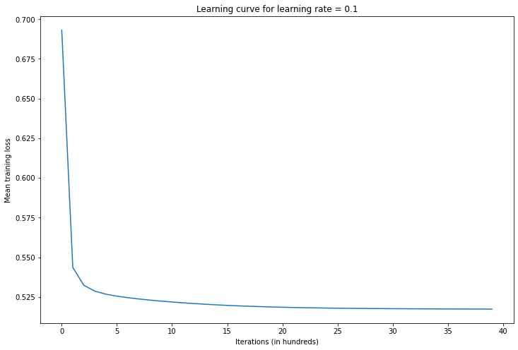

```python
loss_history = np.squeeze(d['mean_loss_history'])
plt.figure(figsize=(12,8))
plt.ylabel('Mean training loss')
plt.xlabel('Iterations (in hundreds)')
plt.title('Learning curve for learning rate = ' + str(d['learning_rate']))
plt.plot(loss_history);
```

```python
def prc_curve(y_true, y_log):
    """
    Arguments:
    y_true: Ground truth labels with size N
    y_log: Probabilities produced by logistic regression model with size N

    Returns:
    auc: Area Under the Curve (AUC)
    tpr_l: List of true positive rate (TPR) values for each scanned threshold
    fpr_l: List of false positive rate (FPR) values for each scanned threshold
    thresholds: Scanned thresholds sorted in decreasing order

    """
    # List of distinct values in y_log, sorted sorted in decreasing order
    thresholds = reversed(sorted(set(y_log))) # <-- SOLUTION
    pr_l, rc_l = [], []

    for threshold in thresholds:
        # Thresholding
        y_thresholded = (y_log >= threshold)

        # True positives
        tp = np.sum(y_true & y_thresholded)
        # True negatives
        tn = np.sum((~y_true) & (~y_thresholded))
        # False positives
        fp = np.sum((~y_true) & y_thresholded)
        # False negatives
        fn = np.sum(y_true & (~y_thresholded))


        pr = tp/(tp + fp)
        rc = tp/(tp + fn)
        pr_l.append(pr)
        rc_l.append(rc)

    # Compute AUC using Trapezoidal rule
    auc = np.trapz(pr_l, rc_l)
    return auc, pr_l, rc_l, thresholds
```

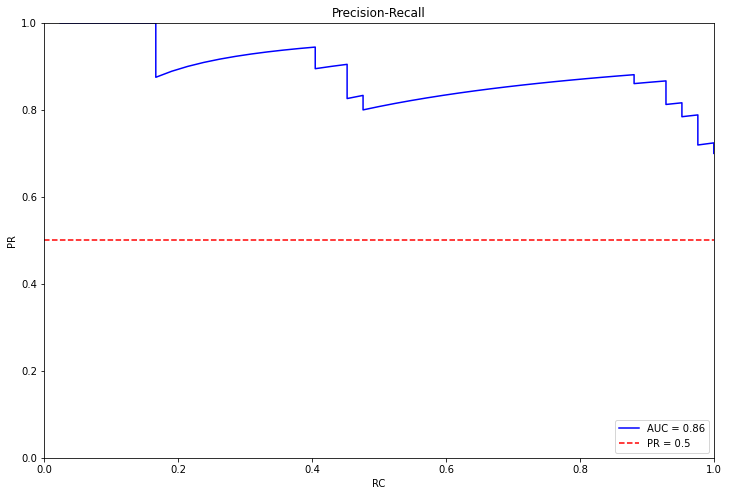

```python
aux_X_brain_test = np.hstack([np.ones((X_brain_test.shape[0],1)), X_brain_test])
y_log = predict_log(aux_X_brain_test, d['beta'])
auc, pr, rc, th = prc_curve(adj_y_test, y_log)

plt.figure(figsize=(12,8))
plt.title(f'Precision-Recall')
plt.plot(rc, pr, 'b', label=f'AUC = {auc:0.2f}')
plt.axhline(y=0.5, color='r', linestyle='--', label='PR = 0.5')
plt.legend(loc='lower right')
plt.xlim([0, 1])
plt.ylim([0, 1])
plt.ylabel('PR')
plt.xlabel('RC')
plt.show()
```

As we know that ranodm classifier has AUC 0.5, our preidctor has AUC around 0.86 which is musch higher than 0.5, showing that our predictor is a pretty decent predictor.

### (2.2.2) (index)

The kernelized version of the logistic regression model is: we replace the usual dot product between $$\mathbf{x}$$ and $$\beta$$ to become, the kernelized dot product: $$ \boldsymbol{\phi}(\mathbf{X}^{(i)}) \cdot \mathbf{w}_{\boldsymbol{\phi}} $$

So the kernelized loss function is equal to: $$ E'(L) = \frac{1}{N} \sum_{i=1}^{N} \left\{ y^{(i)} \log h(\boldsymbol{\phi}(\mathbf{X}^{(i)}) \cdot \mathbf{w}_{\boldsymbol{\phi}} + \beta_0) + \left(1 - y^{(i)}\right) \log \left[1 - h \left(\boldsymbol{\phi}(\mathbf{X}^{(i)}) \cdot \mathbf{w}_{\boldsymbol{\phi}} + \beta_0\right)\right] + \frac{1}{2} \lVert \mathbf{w}_{\boldsymbol{\phi}} \rVert^2 \right) $$

Now using the kernel trick introduced in the lecture notes, we have: $$ \mathbf{w}_{\boldsymbol{\phi}} \cdot \boldsymbol{\phi}(\mathbf{x}) = \mathbf{u}^T \mathbf{K} $$ $$ \mathbf{w}_{\boldsymbol{\phi}} \cdot \mathbf{w}_{\boldsymbol{\phi}} = \mathbf{u}^T \mathbf{K} \mathbf{u} $$

Where $$\mathbf{K}$$ is equal to: $$ \mathbf{K}_{ij} = \boldsymbol{\phi}(\mathbf{x}^{(i)}) \cdot \boldsymbol{\phi}(\mathbf{x}^{(j)}) = k(\mathbf{x}^{(i)}, \mathbf{x}^{(j)}) \text{ (kernel trick)} $$

So using the kernel trick, the loss function becomes: $$ E'(L) = -\frac{1}{N} \sum_{i=1}^{N} \left\{ y^{(i)} \log h(\mathbf{K}^{(i)} \mathbf{u} + \beta_0) + \left(1 - y^{(i)}\right) \log \left[1 - h(\mathbf{K}^{(i)} \mathbf{u} + \beta_0)\right]\right\} + \frac{1}{2} \mathbf{u}^T \mathbf{K} \mathbf{u} $$

So the first term of the sum is just (- t), a convex function, the second term is (t + \log(1+ e^t)) which has positive second derivative, clearly convex. As $$\mathbf{K}$$ is positive semi-definite, we conclude that our loss function is convex.

### (2.2.3) (index)

```python
def LR_kernel(x, y, alpha):
    "return the Kernel function apply on x, y"
    ans  = np.exp(- alpha * np.linalg.norm((x - y), 1))
    return ans
```

```python
def compute_K(X_train, X_test, alpha):
    "calculate the matrix K which is kernel(x_test, x_train)"
    K = np.zeros((X_test.shape[0], X_train.shape[0]))
    for i in range(X_test.shape[0]):
        for j in range(X_train.shape[0]):
            K[i, j] = LR_kernel(X_test[i], X_train[j], alpha)
    return K
```

```python
def kernel_model(X_train, y_train, X_test, y_test, ridge, num_iterations=2000, learning_rate=0.1, print_loss=False, alpha = 0.3):
    # Initialising parameters with zeros
    #calculate the gram matrix K_train
    K_train = compute_K(X_train, X_train, alpha)
    #calcualte the matrix of dot kernel dot product between X_train and X_test
    K_test = compute_K(X_train, X_test, alpha)
    beta = initialise(K_train.shape[1])

    # Gradient descent
    parameters, grads, mean_loss_history = kernel_optimise(K_train, y_train, beta, ridge, num_iterations, learning_rate, print_loss=print_loss)

    # Retrieving parameter vector beta from dictionary 'parameters'
    beta = parameters['beta']

    # Predicting test and training set examples
    N_train, D_train = K_train.shape
    K_train_aug = np.hstack([np.ones((N_train,1)), K_train]) # augmented training inputs of size N x (D+1)
    N_test, D_test = K_test.shape
    K_test_aug = np.hstack([np.ones((N_test,1)), K_test]) # testing training inputs of size N x (D+1) (interception is absored as k[0])
    y_pred_test = predict(K_test_aug, beta)
    y_pred_train = predict(K_train_aug, beta)

    # Printing train/test accuracy
    print('Training accuracy: {} %'.format(100 - np.mean(np.abs(y_pred_train - y_train)) * 100))
    print('Test accuracy: {} %'.format(100 - np.mean(np.abs(y_pred_test - y_test)) * 100))

    # Saving all the information
    d = {'mean_loss_history': mean_loss_history, 'y_pred_test': y_pred_test, 'y_pred_train': y_pred_train, 'beta': beta, 'learning_rate': learning_rate, 'num_iterations': num_iterations}

    return d
```

Mathematical justification of the above method, we notice (motivated by lecture note), we do not need to compute the kernerlize version of the dot product explicitly instead, we can just consider the the e the matrix of dot kernel dot product between X_train and X_test and apply it to w to find the generized kernel dot product.

Also notice that L' (in terms of u) and L (in terms of beta) is bascially the same except the norm(beta)^2 term has changed, so we can use the code we have written for L to do gradient descent fo L' and change a bit in the derritative.

```python
def kernel_propagate(X, y, beta, ridge):
    """
    Arguments:
    X: Data of shape (N, p+1)
    y: True label vector of size N
    beta: Parameter vector, a numpy array of size p+1

    Returns:
    mean_loss: Mean sample loss for the negative log-likelihood
    dbeta: Gradient of the mean sample loss with respect to beta

    """
    y_log = predict_log(X, beta)
    I = np.identity(X.shape[1])
    I[0] = 0.0


    # Mean sample loss function
    mean_loss = - np.mean(y * np.log(y_log) +  (1-y) * np.log(1 - y_log)) + ridge/2 * beta[1: ].T @ X[:, 1:] @ beta[1: ] # the difference between L and L'
    # Derivatives
    tmp = ridge* X[:, 1:] @ beta[1 :]
    tmp = np.insert(tmp, 0, 0, axis = 0)
    dbeta = np.mean(X.T * (y_log - y), axis=1).reshape(-1, 1) + tmp ## difference term comparing to L'
    mean_loss = np.squeeze(mean_loss)

    # Store gradients in a dictionary
    grads = {'dbeta': dbeta}

    return grads, mean_loss
```

```python
def kernel_optimise(X, y, beta, ridge, num_iterations=1000, learning_rate=0.1, print_loss=False):
    """
    Arguments:
    X: Data of shape (N, p+1)
    y: True label vector of size N
    beta: Parameter vector, a numpy array of size p+1
    ridge: the ridge constant
    num_iterations: Number of iterations
    learning_rate: Step size in updating procedure
    print_loss: 'True' to print the mean loss every 100 iterations

    Returns:
    params: Dictionary containing the parameter vector beta
    grads: Dictionary containing the gradient
    mean_loss_history: List of all the mean loss values computed during the optimisation (can be used to plot the learning curve)

    """
    mean_loss_history = []
    N, D = X.shape
    X_aug = np.hstack([np.ones((N,1)), X]) # augmented training inputs of size N x (D+1)
    beta_aug = initialise(D+1) # new beta vector of size (D+1) x 1
    for i in range(num_iterations):

        # Calculating the loss and gradients (hint: use your existing functions)
        grads, mean_loss = kernel_propagate(X_aug, y, beta_aug, ridge)  ## <-- SOLUTION

        # Retrieving derivatives from grads
        dbeta = grads['dbeta']
        # Updating procedure
        beta_aug = beta_aug - learning_rate * dbeta  ## <-- SOLUTION
        # Record the loss values
        if i % 100 == 0:
            mean_loss_history.append(mean_loss)

        # Printing the loss every 100 iterations
        if print_loss and i % 100 == 0:
            print ('Mean loss after iteration %i: %f' %(i, mean_loss))

    # Saving parameters and gradients in dictionary
    params = {'beta': beta_aug}
    grads = {'dbeta': dbeta}

    return params, grads, mean_loss_history
```

```python
# Running the model
adj_y_train =  [y_brain_train == 0]
adj_y_train = 1 - np.array(adj_y_train).astype(int)
adj_y_train = adj_y_train.flatten()
adj_y_test =  [y_brain_test == 0]
adj_y_test = 1 - np.array(adj_y_test).astype(int)
adj_y_test = adj_y_test.flatten()
d = kernel_model(X_brain_train.to_numpy(), adj_y_train, X_brain_test.to_numpy(), adj_y_test, 0.0025, num_iterations=3000, learning_rate=0.1, print_loss=True)
```

```
Mean loss after iteration 0: 0.693147
Mean loss after iteration 100: 0.528921
Mean loss after iteration 200: 0.497216
Mean loss after iteration 300: 0.480677
Mean loss after iteration 400: 0.469650
Mean loss after iteration 500: 0.461516
Mean loss after iteration 600: 0.455191
Mean loss after iteration 700: 0.450113
Mean loss after iteration 800: 0.445947
Mean loss after iteration 900: 0.442472
Mean loss after iteration 1000: 0.439537
Mean loss after iteration 1100: 0.437028
Mean loss after iteration 1200: 0.434864
Mean loss after iteration 1300: 0.432980
Mean loss after iteration 1400: 0.431328
Mean loss after iteration 1500: 0.429867
Mean loss after iteration 1600: 0.428567
Mean loss after iteration 1700: 0.427403
Mean loss after iteration 1800: 0.426354
Mean loss after iteration 1900: 0.425405
Mean loss after iteration 2000: 0.424541
Mean loss after iteration 2100: 0.423750
Mean loss after iteration 2200: 0.423025
Mean loss after iteration 2300: 0.422356
Mean loss after iteration 2400: 0.421736
Mean loss after iteration 2500: 0.421161
Mean loss after iteration 2600: 0.420625
Mean loss after iteration 2700: 0.420124
Mean loss after iteration 2800: 0.419655
Mean loss after iteration 2900: 0.419214
Training accuracy: 87.58620689655173 %
Test accuracy: 73.33333333333333 %
```

[figure not shown]

```python
loss_history = np.squeeze(d['mean_loss_history'])
plt.figure(figsize=(12,8))
plt.ylabel('Mean training loss')
plt.xlabel('Iterations (in hundreds)')
plt.title('alpha = 0.3, Learning curve for learning rate = ' + str(d['learning_rate']))
plt.plot(loss_history);
```

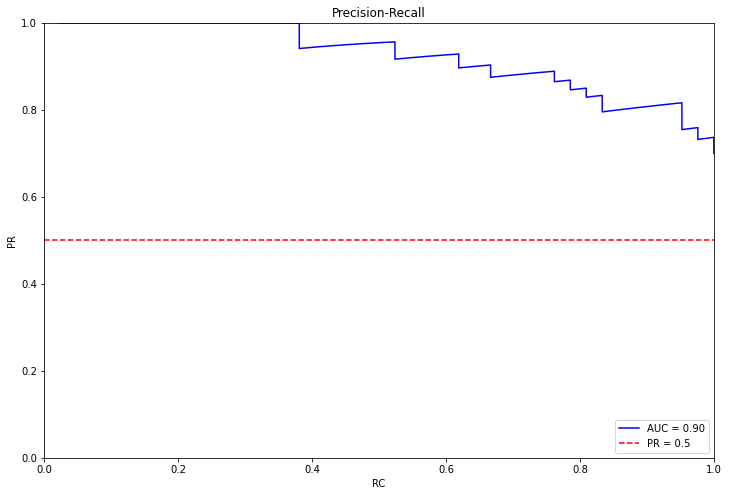

```python
#AUC curve for case alpha = 0.3
K_test = compute_K(X_brain_train.to_numpy(), X_brain_test.to_numpy(), 0.3)
N_test, D_test = K_test.shape
K_test_aug = np.hstack([np.ones((N_test,1)), K_test])
y_log = predict_log(K_test_aug, d['beta'])
auc, pr, rc, th = prc_curve(adj_y_test, y_log)

plt.figure(figsize=(12,8))
plt.title(f'Precision-Recall')
plt.plot(rc, pr, 'b', label=f'AUC = {auc:0.2f}')
plt.axhline(y=0.5, color='r', linestyle='--', label='PR = 0.5')
plt.legend(loc='lower right')
plt.xlim([0, 1])
plt.ylim([0, 1])
plt.ylabel('PR')
plt.xlabel('RC')
plt.show()
```

```python
#case alpha = 100
d = kernel_model(X_brain_train.to_numpy(), adj_y_train, X_brain_test.to_numpy(), adj_y_test, 0.0025, num_iterations=3000, learning_rate=0.1, print_loss=True, alpha = 100)
```

```
Mean loss after iteration 0: 0.693147
Mean loss after iteration 100: 0.613842
Mean loss after iteration 200: 0.598316
Mean loss after iteration 300: 0.584775
Mean loss after iteration 400: 0.572512
Mean loss after iteration 500: 0.561379
Mean loss after iteration 600: 0.551254
Mean loss after iteration 700: 0.542030
Mean loss after iteration 800: 0.533616
Mean loss after iteration 900: 0.525930
Mean loss after iteration 1000: 0.518901
Mean loss after iteration 1100: 0.512468
Mean loss after iteration 1200: 0.506573
Mean loss after iteration 1300: 0.501169
Mean loss after iteration 1400: 0.496212
Mean loss after iteration 1500: 0.491661
Mean loss after iteration 1600: 0.487481
Mean loss after iteration 1700: 0.483641
Mean loss after iteration 1800: 0.480111
Mean loss after iteration 1900: 0.476864
Mean loss after iteration 2000: 0.473879
Mean loss after iteration 2100: 0.471131
Mean loss after iteration 2200: 0.468603
Mean loss after iteration 2300: 0.466275
Mean loss after iteration 2400: 0.464132
Mean loss after iteration 2500: 0.462158
Mean loss after iteration 2600: 0.460340
Mean loss after iteration 2700: 0.458665
Mean loss after iteration 2800: 0.457121
Mean loss after iteration 2900: 0.455699
Training accuracy: 100.0 %
Test accuracy: 70.0 %
```

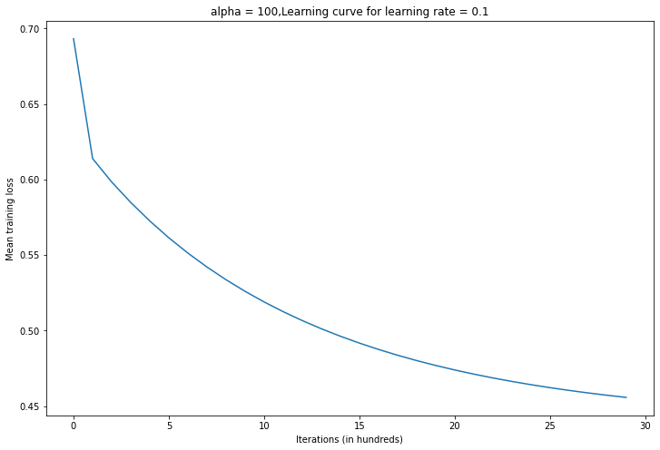

```python
#learnign case for alpha = 100
loss_history = np.squeeze(d['mean_loss_history'])
plt.figure(figsize=(12,8))
plt.ylabel('Mean training loss')
plt.xlabel('Iterations (in hundreds)')
plt.title('alpha = 100,Learning curve for learning rate = ' + str(d['learning_rate']))
plt.plot(loss_history);
```

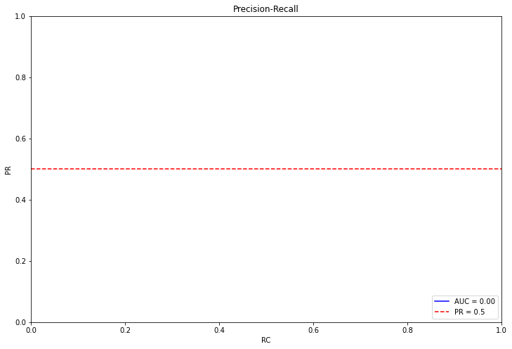

```python
#AUC curve for case alpha  = 100
K_test = compute_K(X_brain_train.to_numpy(), X_brain_test.to_numpy(), 100)
N_test, D_test = K_test.shape
K_test_aug = np.hstack([np.ones((N_test,1)), K_test])
y_log = predict_log(K_test_aug, d['beta'])

auc, pr, rc, th = prc_curve(adj_y_test, y_log)

plt.figure(figsize=(12,8))
plt.title(f'Precision-Recall')
plt.plot(rc, pr, 'b', label=f'AUC = {auc:0.2f}')
plt.axhline(y=0.5, color='r', linestyle='--', label='PR = 0.5')
plt.legend(loc='lower right')
plt.xlim([0, 1])
plt.ylim([0, 1])
plt.ylabel('PR')
plt.xlabel('RC')
plt.show()
```

The performance of the keneralized logistic regression for alpha = 0.3 is slighlty better than that the logistic regreassion, as the AUC is 0.9 which is higher than the logistic regression of alpha = 100. the reason why the kernelized logistic of alpha = 100 is not working because exp(-100 * 1-norm) is a very small number which makes, the prediciton become constant as we can see from below the value of y_log:

```python
print(y_log)
```

```
[0.68397858 0.68397858 0.68397858 0.68397858 0.68397858 0.68397858
 0.68397858 0.68397858 0.68397858 0.68397858 0.68397858 0.68397858
 0.68397858 0.68397858 0.68397858 0.68397858 0.68397858 0.68397858
 0.68397858 0.68397858 0.68397858 0.68397858 0.68397858 0.68397858
 0.68397858 0.68397858 0.68397858 0.68397858 0.68397858 0.68397858
 0.68397858 0.68397858 0.68397858 0.68397858 0.68397858 0.68397858
 0.68397858 0.68397858 0.68397858 0.68397858 0.68397858 0.68397858
 0.68397858 0.68397858 0.68397858 0.68397858 0.68397858 0.68397858
 0.68397858 0.68397858 0.68397858 0.68397858 0.68397858 0.68397858
 0.68397858 0.68397858 0.68397858 0.68397858 0.68397858 0.68397858]
```